# Exportaciones Veritrade de minerales críticos (Latam)

Perú, Chile, Colombia y Ecuador — FOB por partida del cruce USGS × arancel

Fecha de publicación

28 de octubre de 2026

# Contexto

Exportaciones de minerales críticos identificados en el cruce de la lista EE.UU. Se puede revisar el detalle en esta [tabla](https://docs.google.com/spreadsheets/d/1Y181GDonjbUTv3DuH-1dfBxMP2oRGGL6yU8NrS81UbM/edit?gid=1031784788#gid=1031784788)

## Partidas nacionales por país × mineral

Conteo de codigos arancelarios descargados (en base a la `lista_final`). Se puede revisar en: [Minerales críticos Latam × partidas](https://docs.google.com/spreadsheets/d/1Y181GDonjbUTv3DuH-1dfBxMP2oRGGL6yU8NrS81UbM/edit).

[interactive chart not shown]

# Exportaciones Veritrade

Declaraciones de exportación por las partidas de `partidas_unicas`. Total del periodo: **231 683 524,23 TM** netas y **USD 598 666,5 millones** FOB. La métrica prioritaria en tablas y gráficos es el **peso neto (TM)**; el FOB queda como complemento.

| País | Peso neto | Porcentaje peso neto | FOB (USD) | Registros | Periodo |
| --- | --- | --- | --- | --- | --- |
| Chile | 121 287 261,01 TM | 52,4% | USD 384 646,8 millones | 202 737 | 2019–2026 |
| Peru | 107 123 710,64 TM | 46,2% | USD 195 591,5 millones | 55 519 | 2019–2026 |
| Colombia | 1 646 417,16 TM | 0,7% | USD 8 183,6 millones | 18 360 | 2019–2026 |
| Ecuador | 1 626 135,42 TM | 0,7% | USD 10 244,6 millones | 8 503 | 2019–2026 |

## Evolución anual

**Peso neto (TM)**

[interactive chart not shown]

**FOB (USD)**

[interactive chart not shown]

Detalle **por país** (TOC) y **por mineral**: resumen (TM primero), destinos (tabs periodo / 2025), evolución TM/FOB, destinos y exportadoras por mineral.

## Exportaciones · Peru

| Mineral | Peso neto | Porcentaje peso neto | FOB (USD) | Registros |
| --- | --- | --- | --- | --- |
| Cobre | 68 208 222,00 TM | 63,7% | USD 165 807,1 millones | 28 655 |
| Fosfato | 30 494 493,47 TM | 28,5% | USD 3 102,3 millones | 2 063 |
| Plata | 4 295 270,49 TM | 4,0% | USD 9 762,8 millones | 11 615 |
| Plomo | 3 755 110,10 TM | 3,5% | USD 10 789,0 millones | 5 813 |
| Estaño | 199 293,73 TM | 0,2% | USD 6 097,5 millones | 5 736 |
| Baritina | 171 280,85 TM | 0,2% | USD 32,7 millones | 1 636 |
| Arsénico | 40,00 TM | 0,0% | USD 82 480 | 1 |

**Principales destinos**

**Todo el periodo**

| Destino | Peso neto | Porcentaje peso neto | FOB (USD) | Registros |
| --- | --- | --- | --- | --- |
| CHINA | 56 417 813,72 TM | 52,7% | USD 130 231,7 millones | 22 944 |
| ESTADOS UNIDOS | 19 966 953,51 TM | 18,6% | USD 9 094,5 millones | 5 285 |
| BRASIL | 6 836 677,75 TM | 6,4% | USD 4 488,5 millones | 3 567 |
| JAPÓN | 5 607 780,20 TM | 5,2% | USD 12 130,9 millones | 1 409 |
| COREA DEL SUR | 3 908 508,11 TM | 3,6% | USD 9 626,9 millones | 3 197 |
| ESPAÑA | 1 774 411,76 TM | 1,7% | USD 4 007,5 millones | 601 |
| ALEMANIA | 1 623 539,36 TM | 1,5% | USD 3 960,0 millones | 360 |
| INDIA | 1 495 612,72 TM | 1,4% | USD 3 404,8 millones | 793 |
| BULGARIA | 850 985,76 TM | 0,8% | USD 1 978,9 millones | 83 |
| ITALIA | 413 142,75 TM | 0,4% | USD 3 341,1 millones | 2 942 |

**2025**

| Destino | Peso neto | Porcentaje peso neto | FOB (USD) | Registros |
| --- | --- | --- | --- | --- |
| CHINA | 8 924 132,32 TM | 55,0% | USD 24 113,9 millones | 3 931 |
| ESTADOS UNIDOS | 3 397 930,65 TM | 20,9% | USD 1 434,9 millones | 775 |
| BRASIL | 999 557,20 TM | 6,2% | USD 663,2 millones | 557 |
| JAPÓN | 700 555,79 TM | 4,3% | USD 1 958,8 millones | 234 |
| ESPAÑA | 438 187,62 TM | 2,7% | USD 1 026,7 millones | 67 |
| COREA DEL SUR | 298 768,71 TM | 1,8% | USD 898,9 millones | 385 |
| INDIA | 231 377,66 TM | 1,4% | USD 865,9 millones | 201 |
| ALEMANIA | 198 353,67 TM | 1,2% | USD 576,5 millones | 45 |
| BULGARIA | 86 442,61 TM | 0,5% | USD 251,5 millones | 8 |
| ITALIA | 54 631,02 TM | 0,3% | USD 568,8 millones | 717 |

### Cobre

En el periodo, **Cobre** en **Peru** suma 68 208 222,00 TM netas y USD 165 807,1 millones FOB (28 655 registros); en **2025**: 9 638 098,48 TM y USD 28 625,3 millones (4 464 registros).

**Evolución anual**

**Peso neto (TM)**

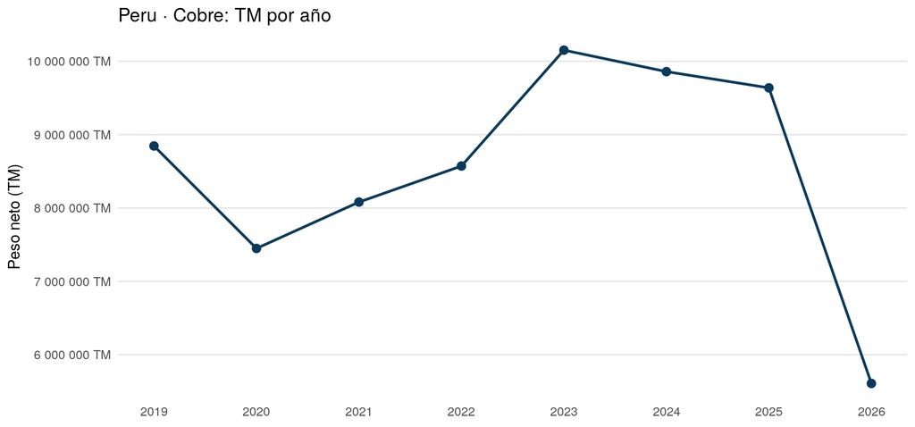

**FOB (USD)**

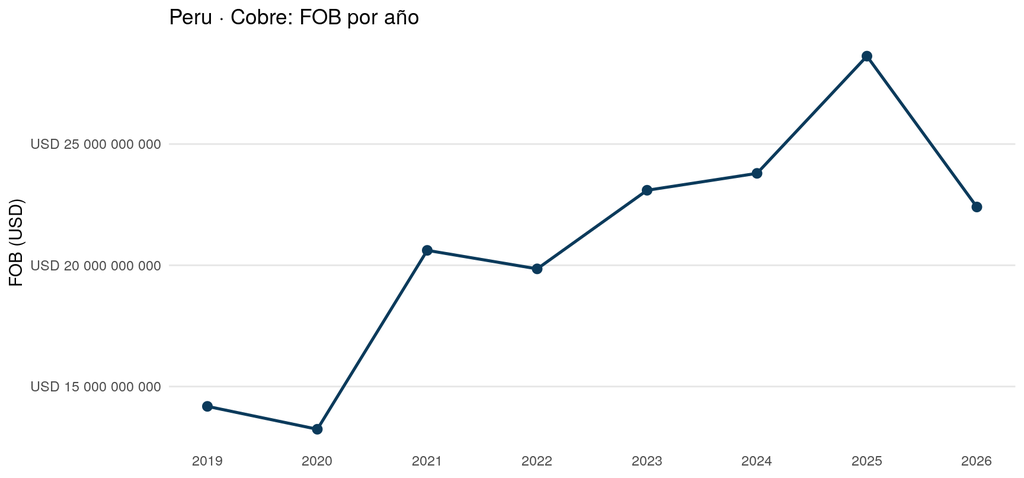

**Principales destinos**

**Todo el periodo**

| Destino | Peso neto | Porcentaje peso neto | FOB (USD) | Registros |
| --- | --- | --- | --- | --- |
| CHINA | 49 613 167,38 TM | 72,7% | USD 116 042,3 millones | 13 435 |
| JAPÓN | 5 509 168,60 TM | 8,1% | USD 11 132,4 millones | 659 |
| COREA DEL SUR | 2 819 212,13 TM | 4,1% | USD 6 396,0 millones | 1 978 |
| ESPAÑA | 1 708 765,52 TM | 2,5% | USD 3 633,5 millones | 193 |
| ALEMANIA | 1 606 912,97 TM | 2,4% | USD 3 737,9 millones | 180 |
| INDIA | 1 257 664,92 TM | 1,8% | USD 3 084,9 millones | 244 |
| BULGARIA | 850 985,76 TM | 1,2% | USD 1 978,9 millones | 83 |
| BRASIL | 491 183,12 TM | 0,7% | USD 3 288,6 millones | 1 855 |
| ESTADOS UNIDOS | 412 396,03 TM | 0,6% | USD 4 057,9 millones | 1 827 |
| ITALIA | 347 147,23 TM | 0,5% | USD 3 080,1 millones | 1 992 |

**2025**

| Destino | Peso neto | Porcentaje peso neto | FOB (USD) | Registros |
| --- | --- | --- | --- | --- |
| CHINA | 7 454 559,17 TM | 77,3% | USD 21 162,2 millones | 2 156 |
| JAPÓN | 684 889,01 TM | 7,1% | USD 1 778,7 millones | 82 |
| ESPAÑA | 387 411,36 TM | 4,0% | USD 990,8 millones | 32 |
| INDIA | 229 505,30 TM | 2,4% | USD 734,3 millones | 63 |
| ALEMANIA | 197 678,32 TM | 2,1% | USD 551,5 millones | 29 |
| COREA DEL SUR | 180 306,24 TM | 1,9% | USD 456,3 millones | 225 |
| BULGARIA | 86 442,61 TM | 0,9% | USD 251,5 millones | 8 |
| ESTADOS UNIDOS | 58 417,84 TM | 0,6% | USD 610,9 millones | 303 |
| ITALIA | 54 502,96 TM | 0,6% | USD 560,5 millones | 379 |
| BRASIL | 48 613,19 TM | 0,5% | USD 489,8 millones | 280 |

**Principales empresas exportadoras**

**Todo el periodo**

| Exportador | Peso neto | Porcentaje peso neto | FOB (USD) | Registros |
| --- | --- | --- | --- | --- |
| SOCIEDAD MINERA CERRO VERDE S.A.A. | 14 794 862,75 TM | 21,7% | USD 26 559,7 millones | 1 702 |
| COMPAÑIA MINERA ANTAMINA S.A. | 11 490 930,77 TM | 16,8% | USD 26 817,2 millones | 1 147 |
| MINERA LAS BAMBAS S.A. | 7 830 959,43 TM | 11,5% | USD 20 970,8 millones | 789 |
| MINERA CHINALCO PERÚ S.A. | 4 590 566,49 TM | 6,7% | USD 8 440,1 millones | 1 008 |
| TRAFIGURA PERU SOCIEDAD ANONIMA CERRADA - TRAFIGURA PERU S.A.C. | 4 481 638,11 TM | 6,6% | USD 8 898,5 millones | 573 |
| SOUTHERN PERU COPPER CORPORATION, SUCURSAL DEL PERÚ | 4 425 667,89 TM | 6,5% | USD 22 030,9 millones | 7 621 |
| COMPAÑIA MINERA ANTAPACCAY S.A. | 4 250 504,45 TM | 6,2% | USD 10 398,3 millones | 435 |
| ANGLO AMERICAN QUELLAVECO S.A. | 4 122 729,91 TM | 6,0% | USD 10 438,7 millones | 426 |
| HUDBAY PERU S.A.C. | 3 154 927,28 TM | 4,6% | USD 6 567,3 millones | 303 |
| GLENCORE PERU S.A.C. | 1 745 532,74 TM | 2,6% | USD 4 191,6 millones | 1 420 |

**2025**

| Exportador | Peso neto | Porcentaje peso neto | FOB (USD) | Registros |
| --- | --- | --- | --- | --- |
| SOCIEDAD MINERA CERRO VERDE S.A.A. | 1 752 411,08 TM | 18,2% | USD 3 980,6 millones | 156 |
| COMPAÑIA MINERA ANTAMINA S.A. | 1 354 990,66 TM | 14,1% | USD 4 331,0 millones | 137 |
| ANGLO AMERICAN QUELLAVECO S.A. | 1 191 000,74 TM | 12,4% | USD 3 115,7 millones | 125 |
| MINERA LAS BAMBAS S.A. | 1 092 007,53 TM | 11,3% | USD 3 345,9 millones | 102 |
| MINERA CHINALCO PERÚ S.A. | 674 910,91 TM | 7,0% | USD 1 618,1 millones | 165 |
| SOUTHERN PERU COPPER CORPORATION, SUCURSAL DEL PERÚ | 674 482,38 TM | 7,0% | USD 3 408,5 millones | 945 |
| TRAFIGURA PERU SOCIEDAD ANONIMA CERRADA - TRAFIGURA PERU S.A.C. | 556 417,90 TM | 5,8% | USD 1 340,0 millones | 73 |
| COMPAÑIA MINERA ANTAPACCAY S.A. | 453 537,81 TM | 4,7% | USD 1 500,2 millones | 51 |
| HUDBAY PERU S.A.C. | 442 782,46 TM | 4,6% | USD 1 362,6 millones | 38 |
| GLENCORE PERU S.A.C. | 378 409,35 TM | 3,9% | USD 941,6 millones | 351 |

### Fosfato

En el periodo, **Fosfato** en **Peru** suma 30 494 493,47 TM netas y USD 3 102,3 millones FOB (2 063 registros); en **2025**: 5 077 922,26 TM y USD 450,7 millones (292 registros).

**Evolución anual**

**Peso neto (TM)**

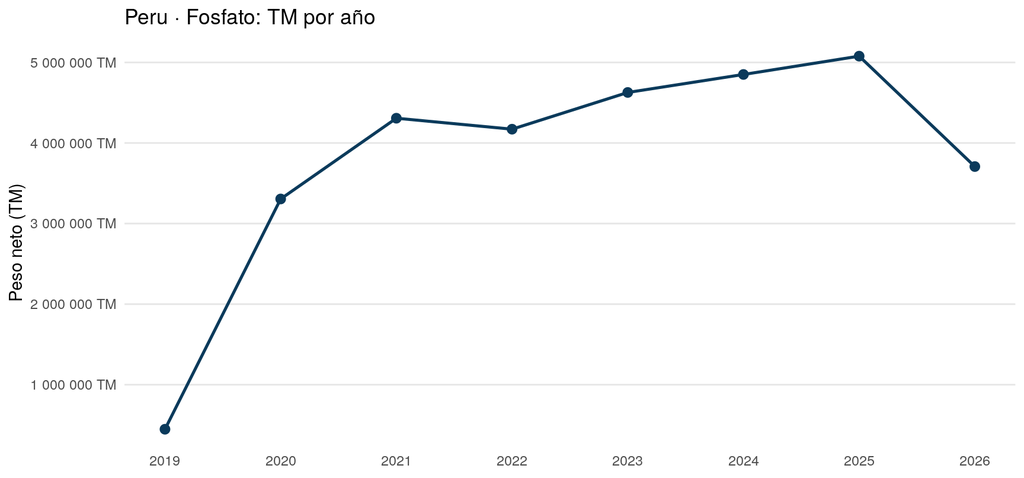

**FOB (USD)**

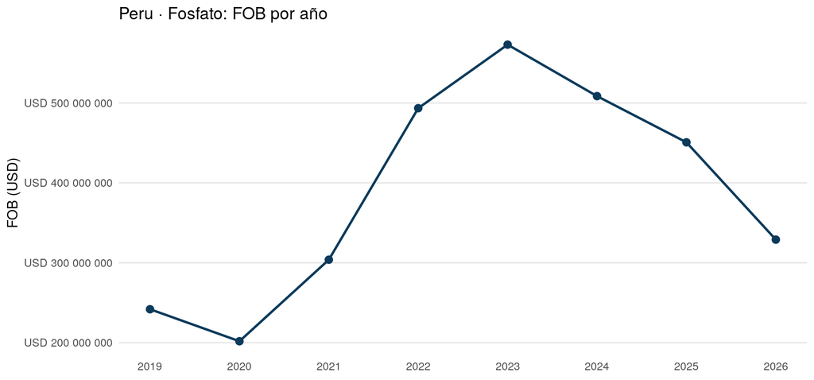

**Principales destinos**

**Todo el periodo**

| Destino | Peso neto | Porcentaje peso neto | FOB (USD) | Registros |
| --- | --- | --- | --- | --- |
| ESTADOS UNIDOS | 19 462 508,03 TM | 63,8% | USD 1 944,6 millones | 402 |
| BRASIL | 6 312 910,53 TM | 20,7% | USD 688,1 millones | 753 |
| ARGENTINA | 2 297 850,33 TM | 7,5% | USD 226,0 millones | 613 |
| INDONESIA | 884 897,31 TM | 2,9% | USD 76,6 millones | 39 |
| CHINA | 378 396,43 TM | 1,2% | USD 34,5 millones | 7 |
| URUGUAY | 257 563,73 TM | 0,8% | USD 26,0 millones | 10 |
| MÉXICO | 245 847,58 TM | 0,8% | USD 30,9 millones | 5 |
| MALASIA | 242 294,02 TM | 0,8% | USD 28,3 millones | 14 |
| INDIA | 234 648,48 TM | 0,8% | USD 25,9 millones | 5 |
| CHILE | 80 304,47 TM | 0,3% | USD 7,4 millones | 28 |

**2025**

| Destino | Peso neto | Porcentaje peso neto | FOB (USD) | Registros |
| --- | --- | --- | --- | --- |
| ESTADOS UNIDOS | 3 325 988,26 TM | 65,5% | USD 294,6 millones | 62 |
| BRASIL | 947 469,17 TM | 18,7% | USD 84,7 millones | 97 |
| ARGENTINA | 361 979,90 TM | 7,1% | USD 32,7 millones | 97 |
| CHINA | 169 550,90 TM | 3,3% | USD 14,8 millones | 3 |
| INDONESIA | 110 000,00 TM | 2,2% | USD 9,4 millones | 4 |
| URUGUAY | 66 000,00 TM | 1,3% | USD 6,1 millones | 2 |
| ESPAÑA | 49 850,60 TM | 1,0% | USD 4,3 millones | 1 |
| MALASIA | 37 262,73 TM | 0,7% | USD 3,3 millones | 2 |
| CHILE | 9 000,00 TM | 0,2% | USD 786 645 | 2 |
| ECUADOR | 766,50 TM | 0,0% | USD 109 800 | 20 |

**Principales empresas exportadoras**

**Todo el periodo**

| Exportador | Peso neto | Porcentaje peso neto | FOB (USD) | Registros |
| --- | --- | --- | --- | --- |
| COMPAÑIA MINERA MISKI MAYO S.R.L. | 30 450 177,89 TM | 99,9% | USD 3 097,1 millones | 1 864 |
| OCEANIA TRADING SOCIEDAD ANONIMA CERRADA | 21 890,00 TM | 0,1% | USD 2,1 millones | 2 |
| FERTILIZANTES Y MINERALES S.A.C. (FERTIMIN) | 10 049,51 TM | 0,0% | USD 1,2 millones | 2 |
| FOSYEIKI S.A.C. | 4 431,14 TM | 0,0% | USD 893 735 | 54 |
| CORPORACION AGROSECHURA PERU S.A.C. - AGROSECHURA PERU | 4 163,63 TM | 0,0% | USD 504 284 | 101 |
| TERRA DEL INCA S.A.C. | 2 133,43 TM | 0,0% | USD 197 212 | 10 |
| MITSUI & CO. (PERÚ) S.A. | 803,00 TM | 0,0% | USD 157 145 | 6 |
| QUIMPAC S.A. | 220,00 TM | 0,0% | USD 34 650 | 3 |
| NATURAL ALLPA S.A.C | 184,00 TM | 0,0% | USD 30 512 | 3 |
| PTC S.A.C | 120,00 TM | 0,0% | USD 26 000 | 2 |

**2025**

| Exportador | Peso neto | Porcentaje peso neto | FOB (USD) | Registros |
| --- | --- | --- | --- | --- |
| COMPAÑIA MINERA MISKI MAYO S.R.L. | 5 077 101,76 TM | 100,0% | USD 450,6 millones | 271 |
| CORPORACION AGROSECHURA PERU S.A.C. - AGROSECHURA PERU | 522,50 TM | 0,0% | USD 67 592 | 15 |
| FOSYEIKI S.A.C. | 146,00 TM | 0,0% | USD 25 232 | 3 |
| PTC S.A.C | 120,00 TM | 0,0% | USD 26 000 | 2 |
| Sin dato | 32,00 TM | 0,0% | USD 3 072 | 1 |

### Plata

En el periodo, **Plata** en **Peru** suma 4 295 270,49 TM netas y USD 9 762,8 millones FOB (11 615 registros); en **2025**: 932 782,76 TM y USD 1 958,7 millones (2 256 registros).

**Evolución anual**

**Peso neto (TM)**

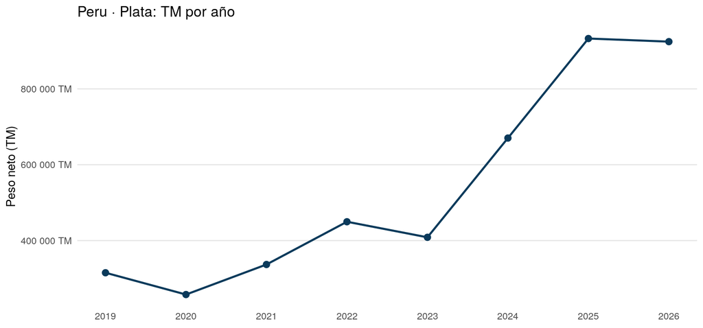

**FOB (USD)**

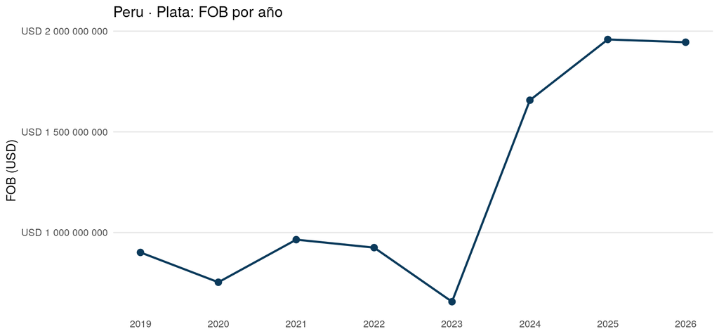

**Principales destinos**

**Todo el periodo**

| Destino | Peso neto | Porcentaje peso neto | FOB (USD) | Registros |
| --- | --- | --- | --- | --- |
| CHINA | 4 078 617,43 TM | 95,0% | USD 6 591,2 millones | 5 692 |
| MALASIA | 78 474,68 TM | 1,8% | USD 65,4 millones | 74 |
| COREA DEL SUR | 71 170,76 TM | 1,7% | USD 422,5 millones | 182 |
| JAPÓN | 10 377,56 TM | 0,2% | USD 88,3 millones | 43 |
| ALEMANIA | 8 356,90 TM | 0,2% | USD 82,4 millones | 37 |
| CANADÁ | 8 108,83 TM | 0,2% | USD 406,2 millones | 172 |
| ESTADOS UNIDOS | 2 704,45 TM | 0,1% | USD 566,2 millones | 744 |
| SUIZA | 2 190,56 TM | 0,1% | USD 611,4 millones | 365 |
| BRASIL | 452,31 TM | 0,0% | USD 442,3 millones | 596 |
| INDIA | 132,00 TM | 0,0% | USD 208,9 millones | 374 |

**2025**

| Destino | Peso neto | Porcentaje peso neto | FOB (USD) | Registros |
| --- | --- | --- | --- | --- |
| CHINA | 898 488,41 TM | 96,3% | USD 1 512,9 millones | 1 143 |
| MALASIA | 19 540,02 TM | 2,1% | USD 13,0 millones | 18 |
| COREA DEL SUR | 9 694,92 TM | 1,0% | USD 54,6 millones | 25 |
| SUECIA | 1 527,51 TM | 0,2% | USD 11,5 millones | 5 |
| SUIZA | 72,19 TM | 0,0% | USD 115,5 millones | 21 |
| BRASIL | 68,52 TM | 0,0% | USD 82,4 millones | 63 |
| ESTADOS UNIDOS | 56,84 TM | 0,0% | USD 65,9 millones | 49 |
| INDIA | 30,30 TM | 0,0% | USD 64,4 millones | 79 |
| CANADÁ | 11,38 TM | 0,0% | USD 13,4 millones | 3 |
| EMIRATOS ÁRABES UNIDOS | 5,37 TM | 0,0% | USD 6,9 millones | 462 |

**Principales empresas exportadoras**

**Todo el periodo**

| Exportador | Peso neto | Porcentaje peso neto | FOB (USD) | Registros |
| --- | --- | --- | --- | --- |
| TRAFIGURA PERU SOCIEDAD ANONIMA CERRADA - TRAFIGURA PERU S.A.C. | 472 089,88 TM | 11,0% | USD 1 670,8 millones | 289 |
| GLENCORE PERU S.A.C. | 262 261,12 TM | 6,1% | USD 895,9 millones | 499 |
| HUMON LATIN AMERICA S.A. | 198 188,06 TM | 4,6% | USD 494,1 millones | 575 |
| COMPAñIA DE MINAS BUENAVENTURA S.A.A. | 196 537,78 TM | 4,6% | USD 227,2 millones | 178 |
| IXM TRADING PERU S.A.C. | 74 390,85 TM | 1,7% | USD 317,9 millones | 59 |
| NEXA RESOURCES CAJAMARQUILLA S.A. | 52 121,45 TM | 1,2% | USD 288,2 millones | 157 |
| COMPANIA MINERA ARES S.A.C. | 41 844,46 TM | 1,0% | USD 773,1 millones | 231 |
| EMPRESA ADMINISTRADORA CERRO S.A.C. | 19 044,92 TM | 0,4% | USD 398,6 millones | 71 |
| SOUTHERN PERU COPPER CORPORATION, SUCURSAL DEL PERÚ | 911,79 TM | 0,0% | USD 864,2 millones | 902 |
| OXIDOS DE PASCO S.A.C. | 510,61 TM | 0,0% | USD 406,7 millones | 116 |

**2025**

| Exportador | Peso neto | Porcentaje peso neto | FOB (USD) | Registros |
| --- | --- | --- | --- | --- |
| TRAFIGURA PERU SOCIEDAD ANONIMA CERRADA - TRAFIGURA PERU S.A.C. | 85 655,95 TM | 9,2% | USD 327,0 millones | 48 |
| NEGOCIO GLOBAL MINERALES S.A.C. | 82 957,15 TM | 8,9% | USD 53,5 millones | 80 |
| GLENCORE PERU S.A.C. | 50 791,57 TM | 5,4% | USD 209,1 millones | 109 |
| COMPAñIA DE MINAS BUENAVENTURA S.A.A. | 42 073,00 TM | 4,5% | USD 84,6 millones | 33 |
| IXM TRADING PERU S.A.C. | 14 325,52 TM | 1,5% | USD 63,0 millones | 15 |
| TRADING PARTNERS PERU S.A.C. | 11 586,51 TM | 1,2% | USD 62,2 millones | 7 |
| INVERSIONES ANTAÑA SOCIEDAD ANONIMA CERRADA - IASAC | 9 068,16 TM | 1,0% | USD 63,0 millones | 25 |
| NEXA RESOURCES CAJAMARQUILLA S.A. | 7 662,43 TM | 0,8% | USD 60,0 millones | 22 |
| EMPRESA ADMINISTRADORA CERRO S.A.C. | 1 107,72 TM | 0,1% | USD 135,3 millones | 21 |
| SOUTHERN PERU COPPER CORPORATION, SUCURSAL DEL PERÚ | 126,61 TM | 0,0% | USD 149,9 millones | 130 |

### Plomo

En el periodo, **Plomo** en **Peru** suma 3 755 110,10 TM netas y USD 10 789,0 millones FOB (5 813 registros); en **2025**: 534 248,93 TM y USD 1 666,4 millones (852 registros).

**Evolución anual**

**Peso neto (TM)**

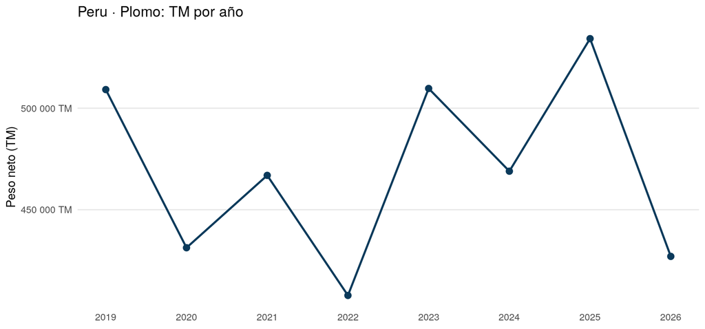

**FOB (USD)**

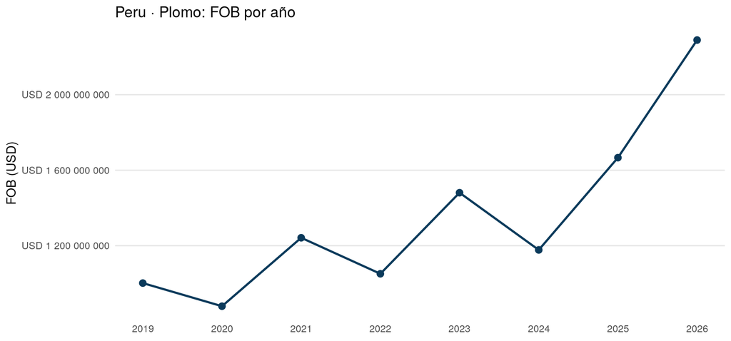

**Principales destinos**

**Todo el periodo**

| Destino | Peso neto | Porcentaje peso neto | FOB (USD) | Registros |
| --- | --- | --- | --- | --- |
| CHINA | 2 326 861,93 TM | 62,0% | USD 6 964,9 millones | 3 397 |
| COREA DEL SUR | 1 012 002,52 TM | 27,0% | USD 2 594,4 millones | 831 |
| BÉLGICA | 73 425,00 TM | 2,0% | USD 278,0 millones | 81 |
| ITALIA | 64 875,82 TM | 1,7% | USD 184,1 millones | 76 |
| JAPÓN | 64 668,40 TM | 1,7% | USD 145,9 millones | 87 |
| PAÍSES BAJOS | 42 097,09 TM | 1,1% | USD 95,3 millones | 29 |
| CANADÁ | 38 018,35 TM | 1,0% | USD 85,3 millones | 6 |
| BRASIL | 30 895,68 TM | 0,8% | USD 69,1 millones | 319 |
| AUSTRALIA | 24 707,59 TM | 0,7% | USD 51,7 millones | 3 |
| MÉXICO | 19 181,68 TM | 0,5% | USD 82,9 millones | 31 |

**2025**

| Destino | Peso neto | Porcentaje peso neto | FOB (USD) | Registros |
| --- | --- | --- | --- | --- |
| CHINA | 396 255,18 TM | 74,2% | USD 1 243,5 millones | 529 |
| COREA DEL SUR | 106 946,62 TM | 20,0% | USD 325,6 millones | 77 |
| BÉLGICA | 10 408,52 TM | 1,9% | USD 32,3 millones | 10 |
| JAPÓN | 10 028,45 TM | 1,9% | USD 33,5 millones | 12 |
| MÉXICO | 3 749,55 TM | 0,7% | USD 10,5 millones | 5 |
| BRASIL | 3 272,22 TM | 0,6% | USD 6,2 millones | 112 |
| ECUADOR | 1 374,47 TM | 0,3% | USD 2,5 millones | 56 |
| MALASIA | 769,71 TM | 0,1% | USD 9,2 millones | 1 |
| ESTADOS UNIDOS | 497,29 TM | 0,1% | USD 987 873 | 14 |
| COLOMBIA | 347,84 TM | 0,1% | USD 655 423 | 10 |

**Principales empresas exportadoras**

**Todo el periodo**

| Exportador | Peso neto | Porcentaje peso neto | FOB (USD) | Registros |
| --- | --- | --- | --- | --- |
| TRAFIGURA PERU SOCIEDAD ANONIMA CERRADA - TRAFIGURA PERU S.A.C. | 1 324 380,33 TM | 35,3% | USD 4 266,8 millones | 925 |
| GLENCORE PERU S.A.C. | 1 134 379,83 TM | 30,2% | USD 2 983,6 millones | 1 599 |
| IXM TRADING PERU S.A.C. | 164 504,36 TM | 4,4% | USD 617,5 millones | 145 |
| COMPAÑIA MINERA CHUNGAR S.A.C. | 126 971,70 TM | 3,4% | USD 355,4 millones | 163 |
| VOLCAN COMPANIA MINERA S.A.A. | 109 743,86 TM | 2,9% | USD 354,4 millones | 138 |
| INVERSIONES ANTAÑA SOCIEDAD ANONIMA CERRADA - IASAC | 92 061,80 TM | 2,5% | USD 352,9 millones | 154 |
| PACIFIC PROCUREMENT SERVICES S.A.C. | 56 388,36 TM | 1,5% | USD 310,9 millones | 44 |
| EMPRESA MINERA LOS QUENUALES S.A.C. | 55 174,14 TM | 1,5% | USD 180,7 millones | 13 |
| TRADING PARTNERS PERU S.A.C. | 50 116,60 TM | 1,3% | USD 194,6 millones | 61 |
| OPTAMINE S.A.C. | 49 551,53 TM | 1,3% | USD 213,7 millones | 71 |

**2025**

| Exportador | Peso neto | Porcentaje peso neto | FOB (USD) | Registros |
| --- | --- | --- | --- | --- |
| TRAFIGURA PERU SOCIEDAD ANONIMA CERRADA - TRAFIGURA PERU S.A.C. | 195 019,50 TM | 36,5% | USD 752,6 millones | 132 |
| GLENCORE PERU S.A.C. | 106 114,38 TM | 19,9% | USD 342,9 millones | 138 |
| COMPAÑIA MINERA CHUNGAR S.A.C. | 24 037,54 TM | 4,5% | USD 60,5 millones | 30 |
| VOLCAN COMPANIA MINERA S.A.A. | 23 211,62 TM | 4,3% | USD 84,5 millones | 29 |
| IXM TRADING PERU S.A.C. | 20 829,25 TM | 3,9% | USD 81,7 millones | 20 |
| INVERSIONES ANTAÑA SOCIEDAD ANONIMA CERRADA - IASAC | 17 307,35 TM | 3,2% | USD 90,0 millones | 33 |
| OPTAMINE S.A.C. | 12 532,62 TM | 2,3% | USD 46,7 millones | 22 |
| EMPRESA ADMINISTRADORA CERRO S.A.C. | 11 580,70 TM | 2,2% | USD 26,2 millones | 17 |
| PACIFIC PROCUREMENT SERVICES S.A.C. | 5 187,73 TM | 1,0% | USD 24,3 millones | 4 |
| HARTREE METALS PERU S.A.C. | 3 606,93 TM | 0,7% | USD 21,7 millones | 5 |

### Estaño

En el periodo, **Estaño** en **Peru** suma 199 293,73 TM netas y USD 6 097,5 millones FOB (5 736 registros); en **2025**: 33 129,69 TM y USD 1 183,4 millones (980 registros).

**Evolución anual**

**Peso neto (TM)**

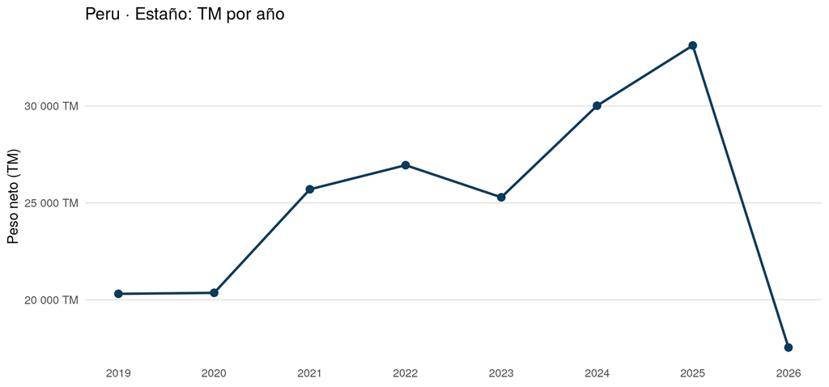

**FOB (USD)**

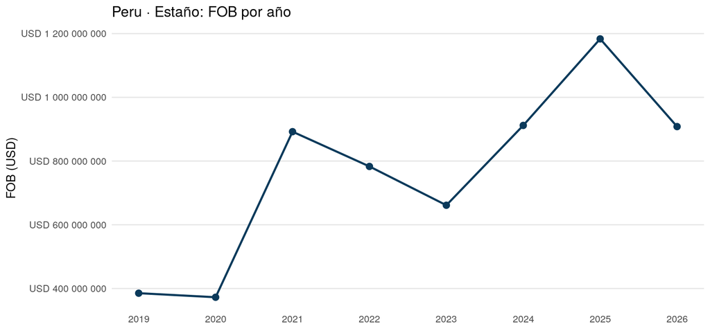

**Principales destinos**

**Todo el periodo**

| Destino | Peso neto | Porcentaje peso neto | FOB (USD) | Registros |
| --- | --- | --- | --- | --- |
| ESTADOS UNIDOS | 80 886,71 TM | 40,6% | USD 2 508,2 millones | 2 009 |
| JAPÓN | 23 565,64 TM | 11,8% | USD 764,3 millones | 620 |
| PAÍSES BAJOS | 22 158,51 TM | 11,1% | USD 660,9 millones | 819 |
| CHINA | 20 770,55 TM | 10,4% | USD 598,8 millones | 413 |
| ESPAÑA | 12 956,72 TM | 6,5% | USD 364,6 millones | 378 |
| REINO UNIDO | 6 877,89 TM | 3,5% | USD 201,8 millones | 244 |
| COREA DEL SUR | 6 122,70 TM | 3,1% | USD 214,0 millones | 206 |
| TURQUÍA | 5 128,36 TM | 2,6% | USD 160,4 millones | 185 |
| ALEMANIA | 4 580,17 TM | 2,3% | USD 131,8 millones | 129 |
| MÉXICO | 4 077,57 TM | 2,0% | USD 133,0 millones | 157 |

**2025**

| Destino | Peso neto | Porcentaje peso neto | FOB (USD) | Registros |
| --- | --- | --- | --- | --- |
| ESTADOS UNIDOS | 12 970,39 TM | 39,2% | USD 462,5 millones | 346 |
| CHINA | 5 278,66 TM | 15,9% | USD 180,4 millones | 100 |
| JAPÓN | 4 038,20 TM | 12,2% | USD 145,4 millones | 139 |
| PAÍSES BAJOS | 2 946,53 TM | 8,9% | USD 109,0 millones | 115 |
| COREA DEL SUR | 1 820,93 TM | 5,5% | USD 62,5 millones | 58 |
| INDIA | 1 751,23 TM | 5,3% | USD 67,0 millones | 54 |
| REINO UNIDO | 1 050,16 TM | 3,2% | USD 37,5 millones | 38 |
| ESPAÑA | 925,65 TM | 2,8% | USD 31,6 millones | 33 |
| ALEMANIA | 675,35 TM | 2,0% | USD 25,0 millones | 16 |
| HONG KONG | 425,30 TM | 1,3% | USD 17,7 millones | 8 |

**Principales empresas exportadoras**

**Todo el periodo**

| Exportador | Peso neto | Porcentaje peso neto | FOB (USD) | Registros |
| --- | --- | --- | --- | --- |
| MINSUR S. A. | 198 718,73 TM | 99,7% | USD 6 088,4 millones | 5 670 |
| ZINC INDUSTRIAS NACIONALES S A | 529,08 TM | 0,3% | USD 7,6 millones | 32 |
| INDUSTRIALES QUIñONES SOCIEDAD ANIMA CER | 14,00 TM | 0,0% | USD 654 413 | 6 |
| FABRICA DE REDES Y CORDELES EL PESCADOR | 11,96 TM | 0,0% | USD 329 487 | 12 |
| ANODOS DEL PERÚ S.A.C. | 10,00 TM | 0,0% | USD 304 730 | 2 |
| UNIQUE S.A. | 6,56 TM | 0,0% | USD 127 173 | 3 |
| ALEACIONES METALURGICAS S.A.C | 2,20 TM | 0,0% | USD 65 196 | 5 |
| ALEACIONES Y METALES NO FERROSO S.A.C. | 1,00 TM | 0,0% | USD 24 500 | 1 |
| ANDERS PERU S.A.C. | 0,19 TM | 0,0% | USD 1 527 | 2 |
| CIMENTACIONES PREFABRICADAS TERRATEST PERU SAC | 0,00 TM | 0,0% | USD 55 | 1 |

**2025**

| Exportador | Peso neto | Porcentaje peso neto | FOB (USD) | Registros |
| --- | --- | --- | --- | --- |
| MINSUR S. A. | 33 118,68 TM | 100,0% | USD 1 183,1 millones | 977 |
| INDUSTRIALES QUIñONES SOCIEDAD ANIMA CER | 6,00 TM | 0,0% | USD 202 280 | 1 |
| ANODOS DEL PERÚ S.A.C. | 5,00 TM | 0,0% | USD 160 730 | 1 |
| ANDERS PERU S.A.C. | 0,01 TM | 0,0% | USD 824 | 1 |

### Baritina

En el periodo, **Baritina** en **Peru** suma 171 280,85 TM netas y USD 32,7 millones FOB (1 636 registros); en **2025**: 23 524,31 TM y USD 4,5 millones (181 registros).

**Evolución anual**

**Peso neto (TM)**

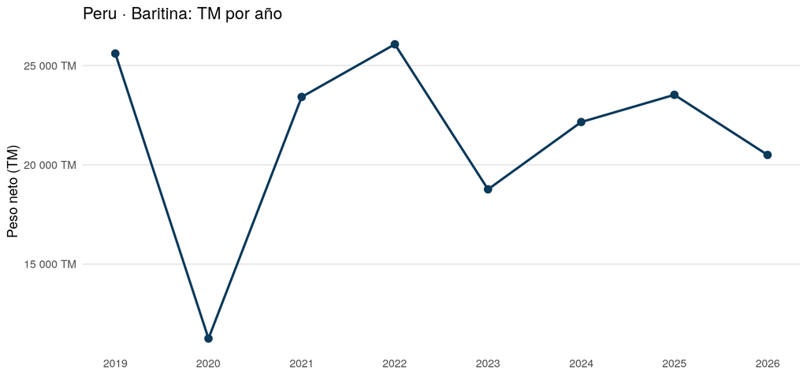

**FOB (USD)**

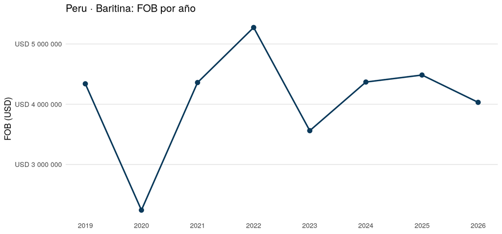

**Principales destinos**

**Todo el periodo**

| Destino | Peso neto | Porcentaje peso neto | FOB (USD) | Registros |
| --- | --- | --- | --- | --- |
| ECUADOR | 74 771,81 TM | 43,7% | USD 13,0 millones | 738 |
| COLOMBIA | 66 690,52 TM | 38,9% | USD 13,3 millones | 427 |
| CHILE | 26 350,23 TM | 15,4% | USD 5,3 millones | 385 |
| CUBA | 1 394,40 TM | 0,8% | USD 283 833 | 6 |
| BRASIL | 1 097,10 TM | 0,6% | USD 428 597 | 39 |
| BOLIVIA | 557,15 TM | 0,3% | USD 280 079 | 26 |
| MÉXICO | 270,00 TM | 0,2% | USD 36 990 | 1 |
| VENEZUELA | 118,00 TM | 0,1% | USD 63 412 | 7 |
| GUATEMALA | 22,70 TM | 0,0% | USD 4 742 | 1 |
| ESPAÑA | 8,01 TM | 0,0% | USD 795 | 4 |

**2025**

| Destino | Peso neto | Porcentaje peso neto | FOB (USD) | Registros |
| --- | --- | --- | --- | --- |
| COLOMBIA | 12 231,86 TM | 52,0% | USD 2,4 millones | 49 |
| ECUADOR | 8 406,40 TM | 35,7% | USD 1,6 millones | 95 |
| CHILE | 2 751,00 TM | 11,7% | USD 473 949 | 29 |
| BRASIL | 134,10 TM | 0,6% | USD 50 024 | 5 |
| COSTA RICA | 0,90 TM | 0,0% | USD 300 | 1 |
| ESTADOS UNIDOS | 0,03 TM | 0,0% | USD 105 | 1 |
| ESPAÑA | 0,01 TM | 0,0% | USD 35 | 1 |

**Principales empresas exportadoras**

**Todo el periodo**

| Exportador | Peso neto | Porcentaje peso neto | FOB (USD) | Registros |
| --- | --- | --- | --- | --- |
| HOLCIM PERÚ AGREGADOS S.A. | 67 087,03 TM | 39,2% | USD 14,1 millones | 1 098 |
| GEOBAR S.A. | 66 797,20 TM | 39,0% | USD 12,2 millones | 237 |
| PTC S.A.C | 22 322,45 TM | 13,0% | USD 3,9 millones | 173 |
| BARIUM SOLUTIONS SOCIEDAD ANONIMA CERRADA | 4 077,50 TM | 2,4% | USD 811 440 | 15 |
| CNPC CHUANQING DRILLING ENGINEERING COMPANY LIMITED - SUCURSAL DEL PERU | 2 430,00 TM | 1,4% | USD 741 610 | 18 |
| Sin dato | 2 200,21 TM | 1,3% | USD 184 518 | 23 |
| MICETRANS E.I.R.L. | 1 429,16 TM | 0,8% | USD 100 701 | 15 |
| ORBIS BUSINESS S.A.C. | 895,44 TM | 0,5% | USD 93 577 | 6 |
| ECONOMET PERU SOCIEDAD ANONIMA CERRADA-ECONOMET PERU S.A.C. | 632,64 TM | 0,4% | USD 95 287 | 3 |
| GWDC PERU S.A.C. | 629,40 TM | 0,4% | USD 165 708 | 5 |

**2025**

| Exportador | Peso neto | Porcentaje peso neto | FOB (USD) | Registros |
| --- | --- | --- | --- | --- |
| GEOBAR S.A. | 11 917,86 TM | 50,7% | USD 2,3 millones | 44 |
| HOLCIM PERÚ AGREGADOS S.A. | 8 778,58 TM | 37,3% | USD 1,7 millones | 108 |
| PTC S.A.C | 2 032,43 TM | 8,6% | USD 352 185 | 17 |
| INVERSIONES FREGYS S.A.C. | 794,00 TM | 3,4% | USD 51 100 | 8 |
| INGENIERIA BIOMEDICA Y RADIACIONES S.A.C. | 0,90 TM | 0,0% | USD 300 | 1 |
| JC PORTAL PERU S.A.C. | 0,50 TM | 0,0% | USD 107 | 1 |
| DIEGO MINERAL’S S.R.L. | 0,04 TM | 0,0% | USD 140 | 2 |

### Arsénico

En el periodo, **Arsénico** en **Peru** suma 40,00 TM netas y USD 82 480 FOB (1 registros).

**Evolución anual**

**Peso neto (TM)**

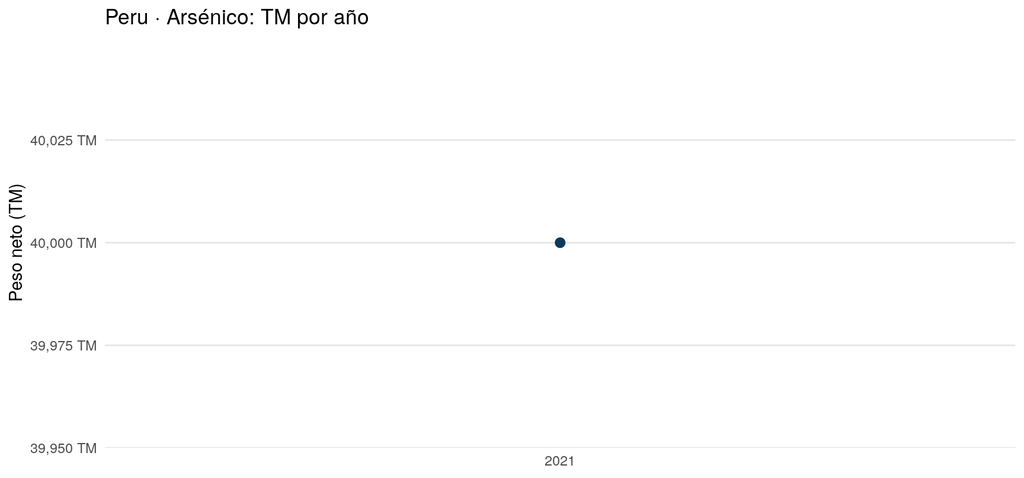

**FOB (USD)**

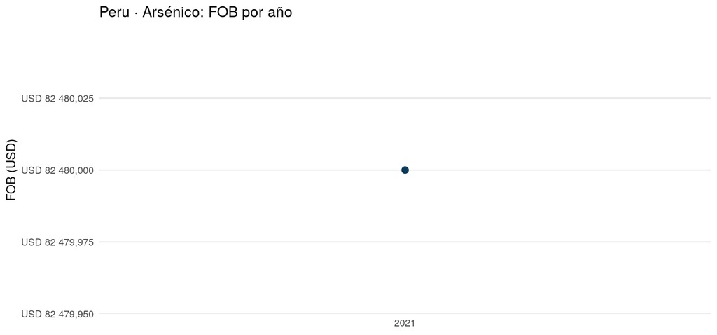

**Principales destinos**

**Todo el periodo**

| Destino | Peso neto | Porcentaje peso neto | FOB (USD) | Registros |
| --- | --- | --- | --- | --- |
| ESTADOS UNIDOS | 40,00 TM | 100,0% | USD 82 480 | 1 |

**2025**

| Destino | Peso neto |
| --- | --- |
| — | — |

**Principales empresas exportadoras**

**Todo el periodo**

| Exportador | Peso neto | Porcentaje peso neto | FOB (USD) | Registros |
| --- | --- | --- | --- | --- |
| ZINC INDUSTRIAS NACIONALES S A | 40,00 TM | 100,0% | USD 82 480 | 1 |

**2025**

| Exportador | Peso neto |
| --- | --- |
| — | — |

## Exportaciones · Chile

| Mineral | Peso neto | Porcentaje peso neto | FOB (USD) | Registros |
| --- | --- | --- | --- | --- |
| Cobre | 119 050 472,84 TM | 98,2% | USD 356 235,9 millones | 68 573 |
| Litio | 1 437 463,12 TM | 1,2% | USD 25 846,1 millones | 127 514 |
| Boro | 707 243,19 TM | 0,6% | USD 526,5 millones | 4 507 |
| Plomo | 89 269,40 TM | 0,1% | USD 176,2 millones | 493 |
| Plata | 1 595,66 TM | 0,0% | USD 1 691,6 millones | 1 413 |
| Fosfato | 1 130,37 TM | 0,0% | USD 174 006 | 30 |
| Renio | 86,43 TM | 0,0% | USD 170,4 millones | 207 |

**Principales destinos**

**Todo el periodo**

| Destino | Peso neto | Porcentaje peso neto | FOB (USD) | Registros |
| --- | --- | --- | --- | --- |
| CHINA | 74 716 612,50 TM | 61,6% | USD 201 285,9 millones | 88 291 |
| JAPÓN | 16 349 940,71 TM | 13,5% | USD 37 302,3 millones | 12 762 |
| COREA DEL SUR | 6 973 093,72 TM | 5,7% | USD 28 861,2 millones | 55 316 |
| ESTADOS UNIDOS | 4 570 929,92 TM | 3,8% | USD 43 291,4 millones | 13 154 |
| INDIA | 4 145 710,06 TM | 3,4% | USD 9 904,4 millones | 1 022 |
| BRASIL | 2 486 340,90 TM | 2,0% | USD 14 606,5 millones | 9 197 |
| ESPAÑA | 2 226 733,35 TM | 1,8% | USD 6 883,8 millones | 1 666 |
| ALEMANIA | 2 043 607,70 TM | 1,7% | USD 5 480,1 millones | 1 457 |
| TAIWÁN, PROVINCIA DE CHINA | 1 257 344,53 TM | 1,0% | USD 6 824,5 millones | 2 458 |
| FRANCIA | 669 112,34 TM | 0,6% | USD 5 808,1 millones | 1 212 |

**2025**

| Destino | Peso neto | Porcentaje peso neto | FOB (USD) | Registros |
| --- | --- | --- | --- | --- |
| CHINA | 10 734 566,19 TM | 63,2% | USD 29 204,0 millones | 14 210 |
| JAPÓN | 2 189 510,96 TM | 12,9% | USD 5 571,6 millones | 2 151 |
| COREA DEL SUR | 797 374,47 TM | 4,7% | USD 3 061,2 millones | 11 059 |
| ESTADOS UNIDOS | 796 669,75 TM | 4,7% | USD 8 272,7 millones | 2 059 |
| INDIA | 790 295,11 TM | 4,7% | USD 2 042,8 millones | 192 |
| ALEMANIA | 356 086,91 TM | 2,1% | USD 1 033,4 millones | 140 |
| ESPAÑA | 304 681,15 TM | 1,8% | USD 1 092,2 millones | 241 |
| BRASIL | 273 419,28 TM | 1,6% | USD 2 239,1 millones | 1 346 |
| FRANCIA | 98 496,13 TM | 0,6% | USD 966,5 millones | 135 |
| TAIWÁN, PROVINCIA DE CHINA | 92 792,10 TM | 0,5% | USD 428,7 millones | 177 |

### Cobre

En el periodo, **Cobre** en **Chile** suma 119 050 472,84 TM netas y USD 356 235,9 millones FOB (68 573 registros); en **2025**: 16 629 038,94 TM y USD 53 873,2 millones (8 291 registros).

**Evolución anual**

**Peso neto (TM)**

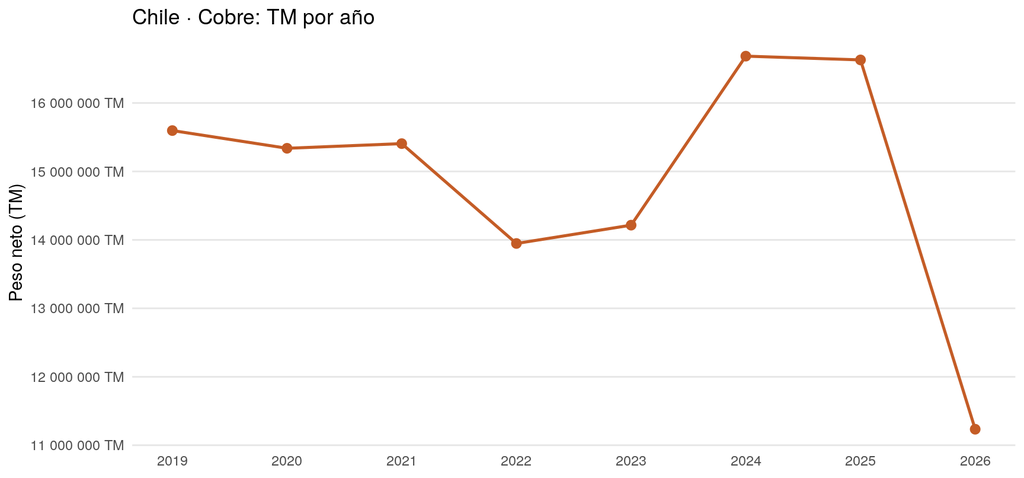

**FOB (USD)**

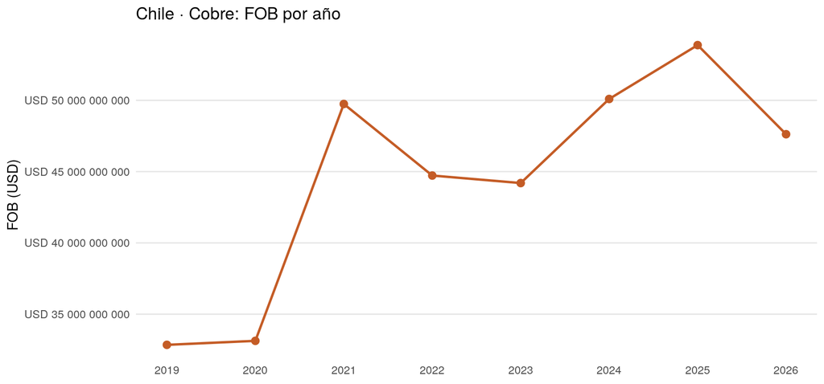

**Principales destinos**

**Todo el periodo**

| Destino | Peso neto | Porcentaje peso neto | FOB (USD) | Registros |
| --- | --- | --- | --- | --- |
| CHINA | 73 494 442,72 TM | 61,7% | USD 184 629,3 millones | 30 309 |
| JAPÓN | 16 235 888,33 TM | 13,6% | USD 35 687,2 millones | 1 771 |
| COREA DEL SUR | 6 610 370,56 TM | 5,6% | USD 23 132,5 millones | 6 533 |
| ESTADOS UNIDOS | 4 493 643,33 TM | 3,8% | USD 41 225,6 millones | 7 851 |
| INDIA | 4 138 582,03 TM | 3,5% | USD 9 873,4 millones | 610 |
| BRASIL | 2 239 619,02 TM | 1,9% | USD 14 341,2 millones | 7 303 |
| ESPAÑA | 2 214 763,95 TM | 1,9% | USD 6 856,0 millones | 1 525 |
| ALEMANIA | 2 021 024,65 TM | 1,7% | USD 5 238,6 millones | 506 |
| TAIWÁN, PROVINCIA DE CHINA | 1 254 484,53 TM | 1,1% | USD 6 810,6 millones | 2 389 |
| FRANCIA | 668 449,34 TM | 0,6% | USD 5 807,6 millones | 1 198 |

**2025**

| Destino | Peso neto | Porcentaje peso neto | FOB (USD) | Registros |
| --- | --- | --- | --- | --- |
| CHINA | 10 524 675,62 TM | 63,3% | USD 27 790,1 millones | 3 355 |
| JAPÓN | 2 174 175,98 TM | 13,1% | USD 5 431,7 millones | 237 |
| INDIA | 789 876,11 TM | 4,7% | USD 2 039,2 millones | 108 |
| ESTADOS UNIDOS | 787 443,46 TM | 4,7% | USD 7 922,3 millones | 1 260 |
| COREA DEL SUR | 733 665,80 TM | 4,4% | USD 2 525,9 millones | 706 |
| ALEMANIA | 355 125,34 TM | 2,1% | USD 1 022,9 millones | 67 |
| ESPAÑA | 304 337,15 TM | 1,8% | USD 1 091,9 millones | 237 |
| BRASIL | 222 010,52 TM | 1,3% | USD 2 181,0 millones | 1 008 |
| FRANCIA | 98 496,13 TM | 0,6% | USD 966,5 millones | 135 |
| TAIWÁN, PROVINCIA DE CHINA | 92 032,10 TM | 0,6% | USD 427,2 millones | 167 |

**Principales empresas exportadoras**

**Todo el periodo**

| Exportador | Peso neto | Porcentaje peso neto | FOB (USD) | Registros |
| --- | --- | --- | --- | --- |
| MINERA ESCONDIDA LIMITADA | 29 577 721,95 TM | 24,8% | USD 71 239,5 millones | 6 022 |
| CORP NACIONAL DEL COBRE DE CHILE | 19 286 937,48 TM | 16,2% | USD 89 646,4 millones | 21 812 |
| CIA MINERA DONA INES DE COLLAHUASI SCM | 14 811 849,80 TM | 12,4% | USD 26 075,9 millones | 1 315 |
| Sin dato | 14 655 904,43 TM | 12,3% | USD 39 438,8 millones | 9 380 |
| ANGLO AMERICAN SUR S.A. | 6 565 608,49 TM | 5,5% | USD 14 441,4 millones | 2 178 |
| MINERA LOS PELAMBRES | 4 713 199,68 TM | 4,0% | USD 12 184,5 millones | 448 |
| SIERRA GORDA SCM | 4 448 230,42 TM | 3,7% | USD 8 424,1 millones | 426 |
| MINERA SPENCE S A | 4 225 609,70 TM | 3,5% | USD 13 330,3 millones | 2 033 |
| CIA CONTRACTUAL MINERA CANDELARIA | 3 421 815,09 TM | 2,9% | USD 8 791,5 millones | 298 |
| MINERA ESPERANZA | 2 913 165,06 TM | 2,4% | USD 10 203,9 millones | 1 180 |

**2025**

| Exportador | Peso neto | Porcentaje peso neto | FOB (USD) | Registros |
| --- | --- | --- | --- | --- |
| MINERA ESCONDIDA LIMITADA | 4 579 510,13 TM | 27,5% | USD 13 010,1 millones | 693 |
| CORP NACIONAL DEL COBRE DE CHILE | 2 877 887,24 TM | 17,3% | USD 13 756,1 millones | 2 339 |
| CIA MINERA DONA INES DE COLLAHUASI SCM | 1 814 471,27 TM | 10,9% | USD 3 238,1 millones | 160 |
| MINERA LOS PELAMBRES | 1 309 902,79 TM | 7,9% | USD 3 278,0 millones | 107 |
| MINERA SPENCE S A | 793 687,05 TM | 4,8% | USD 2 363,3 millones | 232 |
| MINERA ESPERANZA | 776 726,35 TM | 4,7% | USD 2 798,0 millones | 299 |
| ANGLO AMERICAN SUR S.A. | 629 907,55 TM | 3,8% | USD 1 554,6 millones | 212 |
| SIERRA GORDA SCM | 620 814,38 TM | 3,7% | USD 1 353,3 millones | 60 |
| CIA CONTRACTUAL MINERA CANDELARIA | 564 417,95 TM | 3,4% | USD 1 694,8 millones | 49 |
| COMPANIA MINERA TECK QUEBRADA BLANCA S.A. | 550 545,73 TM | 3,3% | USD 1 298,5 millones | 54 |

### Litio

En el periodo, **Litio** en **Chile** suma 1 437 463,12 TM netas y USD 25 846,1 millones FOB (127 514 registros); en **2025**: 248 325,40 TM y USD 2 170,3 millones (24 265 registros).

**Evolución anual**

**Peso neto (TM)**

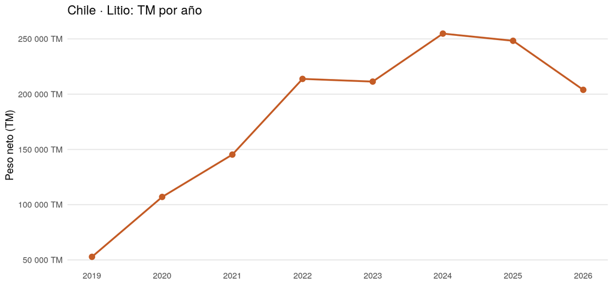

**FOB (USD)**

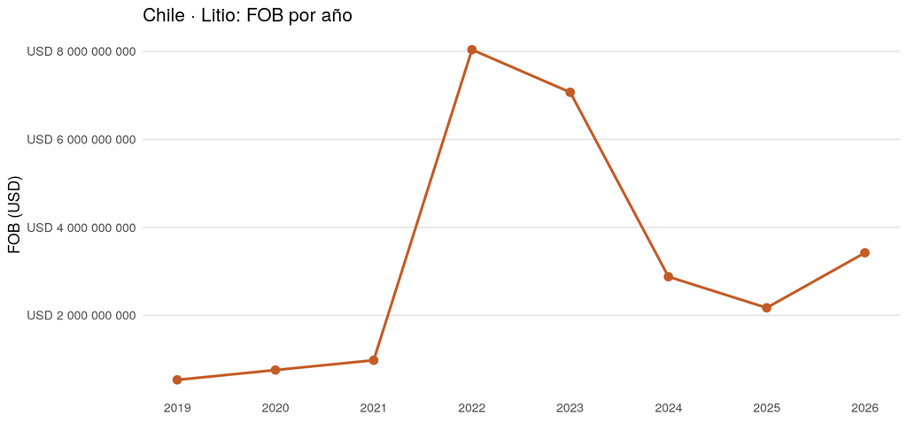

**Principales destinos**

**Todo el periodo**

| Destino | Peso neto | Porcentaje peso neto | FOB (USD) | Registros |
| --- | --- | --- | --- | --- |
| CHINA | 837 779,95 TM | 58,3% | USD 16 371,7 millones | 56 834 |
| COREA DEL SUR | 351 980,27 TM | 24,5% | USD 5 715,1 millones | 48 504 |
| JAPÓN | 92 655,37 TM | 6,4% | USD 1 593,3 millones | 10 794 |
| BÉLGICA | 60 670,72 TM | 4,2% | USD 906,9 millones | 4 245 |
| ESTADOS UNIDOS | 54 799,37 TM | 3,8% | USD 756,4 millones | 3 980 |
| ALEMANIA | 20 462,36 TM | 1,4% | USD 235,5 millones | 874 |
| INDONESIA | 2 530,48 TM | 0,2% | USD 37,8 millones | 506 |
| INDIA | 2 167,50 TM | 0,2% | USD 21,7 millones | 394 |
| POLONIA | 1 898,42 TM | 0,1% | USD 34,1 millones | 416 |
| MÉXICO | 1 434,20 TM | 0,1% | USD 20,6 millones | 87 |

**2025**

| Destino | Peso neto | Porcentaje peso neto | FOB (USD) | Registros |
| --- | --- | --- | --- | --- |
| CHINA | 158 960,27 TM | 64,0% | USD 1 373,2 millones | 10 704 |
| COREA DEL SUR | 62 448,51 TM | 25,1% | USD 533,8 millones | 10 318 |
| JAPÓN | 13 222,74 TM | 5,3% | USD 137,9 millones | 1 892 |
| ESTADOS UNIDOS | 6 687,93 TM | 2,7% | USD 63,7 millones | 552 |
| BÉLGICA | 4 700,80 TM | 1,9% | USD 41,6 millones | 542 |
| ALEMANIA | 885,50 TM | 0,4% | USD 7,8 millones | 57 |
| INDIA | 419,00 TM | 0,2% | USD 3,6 millones | 84 |
| INDONESIA | 200,02 TM | 0,1% | USD 1,8 millones | 40 |
| REINO UNIDO | 168,00 TM | 0,1% | USD 1,4 millones | 7 |
| BRASIL | 135,00 TM | 0,1% | USD 1,6 millones | 27 |

**Principales empresas exportadoras**

**Todo el periodo**

| Exportador | Peso neto | Porcentaje peso neto | FOB (USD) | Registros |
| --- | --- | --- | --- | --- |
| S Q M SALAR S A | 1 011 559,77 TM | 70,4% | USD 20 329,7 millones | 105 798 |
| SOC CHILENA DE LITIO LTDA | 358 741,40 TM | 25,0% | USD 4 814,5 millones | 17 350 |
| Sin dato | 55 823,63 TM | 3,9% | USD 514,7 millones | 3 812 |
| YUMBES S C M | 9 268,34 TM | 0,6% | USD 165,1 millones | 452 |
| OUTOTEC (CHILE) S A | 2 069,98 TM | 0,1% | USD 22,1 millones | 102 |

**2025**

| Exportador | Peso neto | Porcentaje peso neto | FOB (USD) | Registros |
| --- | --- | --- | --- | --- |
| S Q M SALAR S A | 175 276,62 TM | 70,6% | USD 1 491,2 millones | 20 495 |
| SOC CHILENA DE LITIO LTDA | 73 048,79 TM | 29,4% | USD 679,1 millones | 3 770 |

### Boro

En el periodo, **Boro** en **Chile** suma 707 243,19 TM netas y USD 526,5 millones FOB (4 507 registros); en **2025**: 102 203,77 TM y USD 84,8 millones (627 registros).

**Evolución anual**

**Peso neto (TM)**

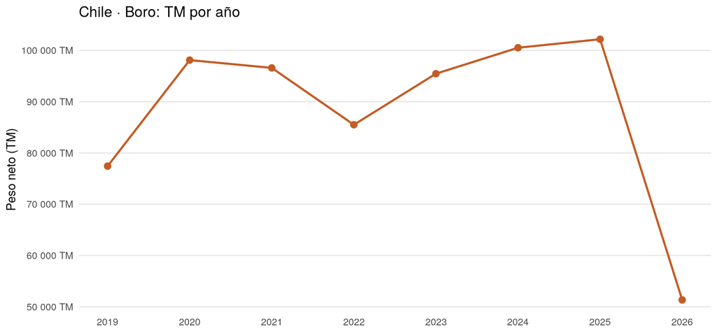

**FOB (USD)**

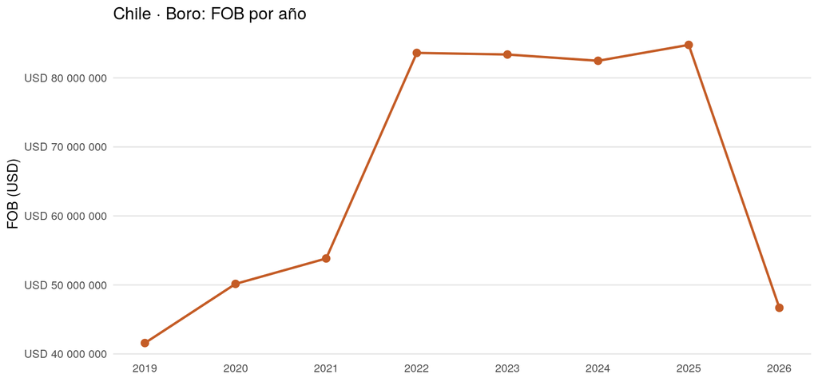

**Principales destinos**

**Todo el periodo**

| Destino | Peso neto | Porcentaje peso neto | FOB (USD) | Registros |
| --- | --- | --- | --- | --- |
| CHINA | 382 492,90 TM | 54,1% | USD 261,6 millones | 1 132 |
| BRASIL | 198 446,40 TM | 28,1% | USD 164,9 millones | 1 630 |
| MALASIA | 29 725,00 TM | 4,2% | USD 21,1 millones | 131 |
| JAPÓN | 20 410,50 TM | 2,9% | USD 19,4 millones | 180 |
| ESTADOS UNIDOS | 19 930,86 TM | 2,8% | USD 14,4 millones | 298 |
| COREA DEL SUR | 8 851,25 TM | 1,3% | USD 7,6 millones | 242 |
| ESPAÑA | 6 441,00 TM | 0,9% | USD 4,0 millones | 62 |
| ITALIA | 6 147,65 TM | 0,9% | USD 5,8 millones | 39 |
| MÉXICO | 5 498,00 TM | 0,8% | USD 4,7 millones | 103 |
| PAKISTÁN | 3 666,00 TM | 0,5% | USD 2,9 millones | 134 |

**2025**

| Destino | Peso neto | Porcentaje peso neto | FOB (USD) | Registros |
| --- | --- | --- | --- | --- |
| CHINA | 50 821,00 TM | 49,7% | USD 40,5 millones | 149 |
| BRASIL | 38 990,00 TM | 38,1% | USD 33,2 millones | 273 |
| ESTADOS UNIDOS | 2 305,12 TM | 2,3% | USD 2,0 millones | 23 |
| MALASIA | 1 984,00 TM | 1,9% | USD 1,7 millones | 18 |
| JAPÓN | 1 980,00 TM | 1,9% | USD 1,8 millones | 20 |
| COREA DEL SUR | 1 260,00 TM | 1,2% | USD 1,3 millones | 29 |
| TAIWÁN, PROVINCIA DE CHINA | 600,00 TM | 0,6% | USD 529 782 | 2 |
| MÉXICO | 526,00 TM | 0,5% | USD 487 681 | 12 |
| VIETNAM | 450,00 TM | 0,4% | USD 375 229 | 7 |
| BANGLADESH | 417,00 TM | 0,4% | USD 395 476 | 11 |

**Principales empresas exportadoras**

**Todo el periodo**

| Exportador | Peso neto | Porcentaje peso neto | FOB (USD) | Registros |
| --- | --- | --- | --- | --- |
| QUIBORAX S.A. | 700 451,20 TM | 99,0% | USD 522,1 millones | 4 449 |
| Sin dato | 5 730,96 TM | 0,8% | USD 3,1 millones | 46 |
| S Q M SALAR S A | 1 055,00 TM | 0,1% | USD 1,4 millones | 5 |
| DEXIMA S A | 6,00 TM | 0,0% | USD 12 839 | 2 |
| EVELYN DEL CARMEN VALDERRAMA M | 0,02 TM | 0,0% | USD 1 302 | 3 |
| COMERCIALIZADORA CORDOVA SAEZ LIMITADA | 0,01 TM | 0,0% | USD 679 | 2 |

**2025**

| Exportador | Peso neto | Porcentaje peso neto | FOB (USD) | Registros |
| --- | --- | --- | --- | --- |
| QUIBORAX S.A. | 102 203,77 TM | 100,0% | USD 84,8 millones | 627 |

### Plomo

En el periodo, **Plomo** en **Chile** suma 89 269,40 TM netas y USD 176,2 millones FOB (493 registros); en **2025**: 13 568,09 TM y USD 26,9 millones (48 registros).

**Evolución anual**

**Peso neto (TM)**

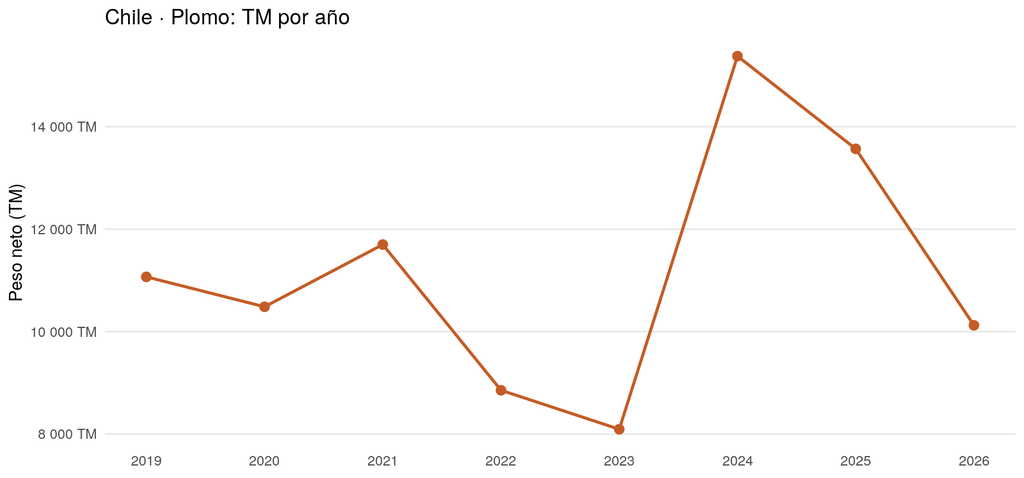

**FOB (USD)**

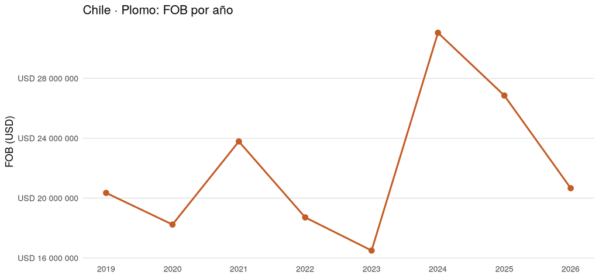

**Principales destinos**

**Todo el periodo**

| Destino | Peso neto | Porcentaje peso neto | FOB (USD) | Registros |
| --- | --- | --- | --- | --- |
| BRASIL | 47 871,87 TM | 53,6% | USD 94,1 millones | 178 |
| COLOMBIA | 17 972,74 TM | 20,1% | USD 35,6 millones | 129 |
| INDIA | 4 960,52 TM | 5,6% | USD 9,3 millones | 18 |
| ESPAÑA | 4 664,15 TM | 5,2% | USD 8,6 millones | 42 |
| PERÚ | 2 354,29 TM | 2,6% | USD 4,9 millones | 25 |
| COREA DEL SUR | 1 890,67 TM | 2,1% | USD 3,5 millones | 5 |
| CHINA | 1 889,77 TM | 2,1% | USD 5,0 millones | 12 |
| ESTADOS UNIDOS | 1 276,75 TM | 1,4% | USD 2,4 millones | 7 |
| BÉLGICA | 1 183,39 TM | 1,3% | USD 2,2 millones | 12 |
| ESLOVENIA | 1 107,72 TM | 1,2% | USD 2,0 millones | 5 |

**2025**

| Destino | Peso neto | Porcentaje peso neto | FOB (USD) | Registros |
| --- | --- | --- | --- | --- |
| BRASIL | 12 283,76 TM | 90,5% | USD 23,4 millones | 38 |
| COLOMBIA | 845,05 TM | 6,2% | USD 1,7 millones | 3 |
| MÉXICO | 197,37 TM | 1,5% | USD 1,4 millones | 2 |
| JAPÓN | 132,24 TM | 1,0% | USD 236 613 | 2 |
| CHINA | 109,30 TM | 0,8% | USD 193 207 | 2 |
| CANADÁ | 0,36 TM | 0,0% | USD 430 | 1 |

**Principales empresas exportadoras**

**Todo el periodo**

| Exportador | Peso neto | Porcentaje peso neto | FOB (USD) | Registros |
| --- | --- | --- | --- | --- |
| PROC.DE RESIDUOS INDUST. LTDA | 55 352,03 TM | 62,0% | USD 108,1 millones | 229 |
| Sin dato | 32 876,98 TM | 36,8% | USD 65,2 millones | 243 |
| INDUSTRIA PROVEEDORA DE PARTES METALURGICAS LTDA | 726,18 TM | 0,8% | USD 2,3 millones | 10 |
| BATERIAS ETNA CHILE S.A. | 154,32 TM | 0,2% | USD 289 093 | 3 |
| RECICLADORA AMBIENTAL LIMITADA | 120,27 TM | 0,1% | USD 210 471 | 2 |
| COMERCIAL Y DE INVERSIONES 4G | 39,59 TM | 0,0% | USD 67 681 | 1 |
| ALFRED H KNIGHT INTERNATIONAL | 0,03 TM | 0,0% | USD 600 | 5 |

**2025**

| Exportador | Peso neto | Porcentaje peso neto | FOB (USD) | Registros |
| --- | --- | --- | --- | --- |
| PROC.DE RESIDUOS INDUST. LTDA | 13 175,17 TM | 97,1% | USD 25,2 millones | 42 |
| INDUSTRIA PROVEEDORA DE PARTES METALURGICAS LTDA | 392,56 TM | 2,9% | USD 1,7 millones | 5 |
| Sin dato | 0,36 TM | 0,0% | USD 430 | 1 |

### Plata

En el periodo, **Plata** en **Chile** suma 1 595,66 TM netas y USD 1 691,6 millones FOB (1 413 registros); en **2025**: 225,99 TM y USD 255,6 millones (188 registros).

**Evolución anual**

**Peso neto (TM)**

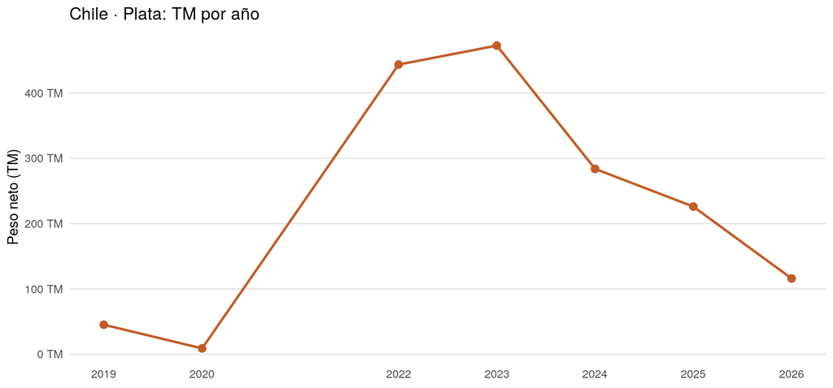

**FOB (USD)**

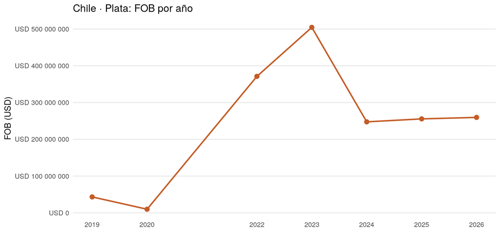

**Principales destinos**

**Todo el periodo**

| Destino | Peso neto | Porcentaje peso neto | FOB (USD) | Registros |
| --- | --- | --- | --- | --- |
| ESTADOS UNIDOS | 1 197,61 TM | 75,1% | USD 1 133,2 millones | 878 |
| CANADÁ | 180,86 TM | 11,3% | USD 281,0 millones | 139 |
| SUIZA | 173,13 TM | 10,9% | USD 208,6 millones | 368 |
| REINO UNIDO | 32,91 TM | 2,1% | USD 50,7 millones | 20 |
| CHINA | 6,47 TM | 0,4% | USD 16,7 millones | 2 |
| FRANCIA | 3,00 TM | 0,2% | USD 2 550 | 1 |
| JAPÓN | 0,90 TM | 0,1% | USD 639 744 | 1 |
| BRASIL | 0,71 TM | 0,0% | USD 575 689 | 2 |
| ARGENTINA | 0,05 TM | 0,0% | USD 48 352 | 1 |
| PERÚ | 0,01 TM | 0,0% | USD 807 | 1 |

**2025**

| Destino | Peso neto | Porcentaje peso neto | FOB (USD) | Registros |
| --- | --- | --- | --- | --- |
| ESTADOS UNIDOS | 206,09 TM | 91,2% | USD 230,7 millones | 170 |
| REINO UNIDO | 19,52 TM | 8,6% | USD 24,3 millones | 13 |
| SUIZA | 0,38 TM | 0,2% | USD 672 124 | 5 |

**Principales empresas exportadoras**

**Todo el periodo**

| Exportador | Peso neto | Porcentaje peso neto | FOB (USD) | Registros |
| --- | --- | --- | --- | --- |
| CORP NACIONAL DEL COBRE DE CHILE | 1 278,13 TM | 80,1% | USD 1 232,9 millones | 933 |
| MINERA SANTA ROSA S C M | 154,80 TM | 9,7% | USD 254,5 millones | 121 |
| Sin dato | 107,37 TM | 6,7% | USD 146,4 millones | 105 |
| ARGOR-HERAEUS LATIN AMERICA SPA | 52,99 TM | 3,3% | USD 55,8 millones | 250 |
| PLANTA RECUPERADORA DE METALES SPA | 2,37 TM | 0,1% | USD 2,0 millones | 4 |

**2025**

| Exportador | Peso neto | Porcentaje peso neto | FOB (USD) | Registros |
| --- | --- | --- | --- | --- |
| CORP NACIONAL DEL COBRE DE CHILE | 225,46 TM | 99,8% | USD 254,7 millones | 182 |
| ARGOR-HERAEUS LATIN AMERICA SPA | 0,38 TM | 0,2% | USD 672 124 | 5 |
| PLANTA RECUPERADORA DE METALES SPA | 0,15 TM | 0,1% | USD 193 630 | 1 |

### Fosfato

En el periodo, **Fosfato** en **Chile** suma 1 130,37 TM netas y USD 174 006 FOB (30 registros); en **2025**: 360,21 TM y USD 55 160 (11 registros).

**Evolución anual**

**Peso neto (TM)**

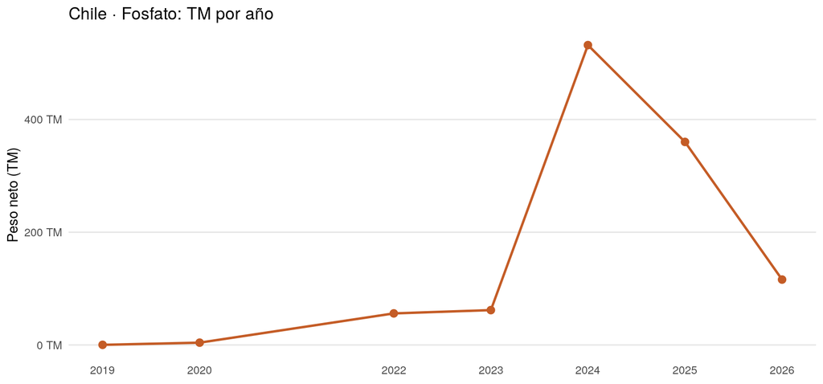

**FOB (USD)**

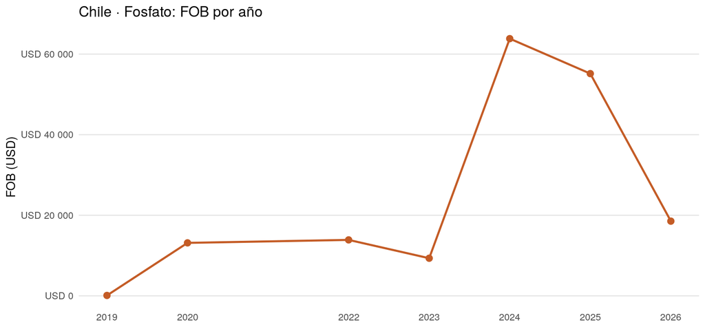

**Principales destinos**

**Todo el periodo**

| Destino | Peso neto | Porcentaje peso neto | FOB (USD) | Registros |
| --- | --- | --- | --- | --- |
| ARGENTINA | 980,41 TM | 86,7% | USD 123 113 | 22 |
| COSTA RICA | 140,00 TM | 12,4% | USD 35 619 | 3 |
| PERÚ | 5,77 TM | 0,5% | USD 1 926 | 2 |
| PAÍSES BAJOS | 4,00 TM | 0,4% | USD 10 143 | 1 |
| BRASIL | 0,10 TM | 0,0% | USD 200 | 1 |
| URUGUAY | 0,09 TM | 0,0% | USD 3 006 | 1 |

**2025**

| Destino | Peso neto | Porcentaje peso neto | FOB (USD) | Registros |
| --- | --- | --- | --- | --- |
| ARGENTINA | 280,21 TM | 77,8% | USD 31 361 | 9 |
| COSTA RICA | 80,00 TM | 22,2% | USD 23 799 | 2 |

**Principales empresas exportadoras**

**Todo el periodo**

| Exportador | Peso neto | Porcentaje peso neto | FOB (USD) | Registros |
| --- | --- | --- | --- | --- |
| Sin dato | 1 130,27 TM | 100,0% | USD 173 806 | 29 |
| BASF CHILE S A | 0,10 TM | 0,0% | USD 200 | 1 |

**2025**

| Exportador | Peso neto | Porcentaje peso neto | FOB (USD) | Registros |
| --- | --- | --- | --- | --- |
| Sin dato | 360,21 TM | 100,0% | USD 55 160 | 11 |

### Renio

En el periodo, **Renio** en **Chile** suma 86,43 TM netas y USD 170,4 millones FOB (207 registros); en **2025**: 29,26 TM y USD 58,9 millones (77 registros).

**Evolución anual**

**Peso neto (TM)**

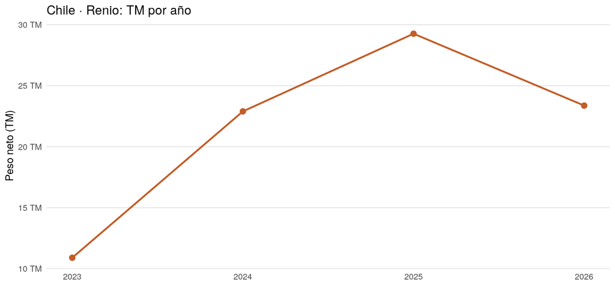

**FOB (USD)**

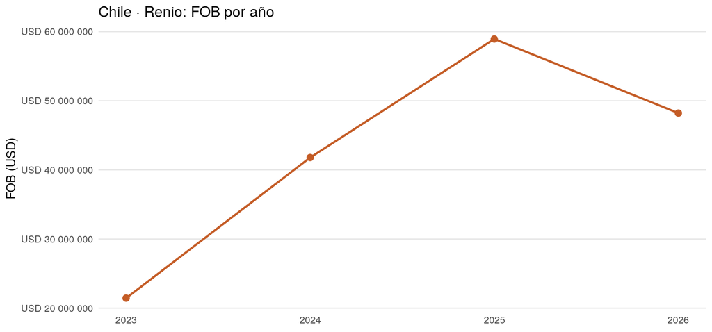

**Principales destinos**

**Todo el periodo**

| Destino | Peso neto | Porcentaje peso neto | FOB (USD) | Registros |
| --- | --- | --- | --- | --- |
| ESTADOS UNIDOS | 82,00 TM | 94,9% | USD 159,3 millones | 140 |
| ALEMANIA | 1,50 TM | 1,7% | USD 4,4 millones | 19 |
| AUSTRIA | 1,09 TM | 1,3% | USD 2,5 millones | 10 |
| COREA DEL SUR | 0,98 TM | 1,1% | USD 2,4 millones | 32 |
| CHINA | 0,70 TM | 0,8% | USD 1,6 millones | 2 |
| CANADÁ | 0,16 TM | 0,2% | USD 192 148 | 1 |
| SUIZA | 0,00 TM | 0,0% | USD 11 161 | 2 |
| REPÚBLICA CHECA | 0,00 TM | 0,0% | USD 1 082 | 1 |

**2025**

| Destino | Peso neto | Porcentaje peso neto | FOB (USD) | Registros |
| --- | --- | --- | --- | --- |
| ESTADOS UNIDOS | 27,16 TM | 92,8% | USD 54,1 millones | 54 |
| ALEMANIA | 1,07 TM | 3,7% | USD 2,6 millones | 13 |
| AUSTRIA | 0,72 TM | 2,5% | USD 1,8 millones | 3 |
| CANADÁ | 0,16 TM | 0,5% | USD 192 148 | 1 |
| COREA DEL SUR | 0,15 TM | 0,5% | USD 266 516 | 6 |

**Principales empresas exportadoras**

**Todo el periodo**

| Exportador | Peso neto | Porcentaje peso neto | FOB (USD) | Registros |
| --- | --- | --- | --- | --- |
| MOLIBDENOS Y METALES S A | 85,23 TM | 98,6% | USD 168,7 millones | 195 |
| CORP NACIONAL DEL COBRE DE CHILE | 1,20 TM | 1,4% | USD 1,7 millones | 12 |

**2025**

| Exportador | Peso neto | Porcentaje peso neto | FOB (USD) | Registros |
| --- | --- | --- | --- | --- |
| MOLIBDENOS Y METALES S A | 28,36 TM | 96,9% | USD 57,7 millones | 68 |
| CORP NACIONAL DEL COBRE DE CHILE | 0,90 TM | 3,1% | USD 1,3 millones | 9 |

## Exportaciones · Colombia

| Mineral | Peso neto | Porcentaje peso neto | FOB (USD) | Registros |
| --- | --- | --- | --- | --- |
| Níquel | 1 012 030,94 TM | 61,5% | USD 4 251,5 millones | 2 755 |
| Cobre | 631 784,12 TM | 38,4% | USD 3 629,3 millones | 13 450 |
| Plata | 1 945,45 TM | 0,1% | USD 93,1 millones | 847 |
| Fosfato | 650,00 TM | 0,0% | USD 111 574 | 3 |
| Platino | 6,65 TM | 0,0% | USD 209,6 millones | 1 305 |

**Principales destinos**

**Todo el periodo**

| Destino | Peso neto | Porcentaje peso neto | FOB (USD) | Registros |
| --- | --- | --- | --- | --- |
| CHINA | 969 367,69 TM | 58,9% | USD 3 945,5 millones | 6 752 |
| PAÍSES BAJOS | 132 995,00 TM | 8,1% | USD 506,6 millones | 502 |
| COREA DEL SUR | 112 365,81 TM | 6,8% | USD 672,6 millones | 2 740 |
| JAPÓN | 64 614,98 TM | 3,9% | USD 315,4 millones | 885 |
| INDIA | 44 873,29 TM | 2,7% | USD 235,1 millones | 932 |
| ALEMANIA | 36 151,05 TM | 2,2% | USD 144,0 millones | 215 |
| ITALIA | 34 416,51 TM | 2,1% | USD 181,8 millones | 185 |
| PERÚ | 33 971,21 TM | 2,1% | USD 671,2 millones | 158 |
| ESTADOS UNIDOS | 30 524,34 TM | 1,9% | USD 285,3 millones | 896 |
| BRASIL | 20 066,90 TM | 1,2% | USD 134,4 millones | 790 |

**2025**

| Destino | Peso neto | Porcentaje peso neto | FOB (USD) | Registros |
| --- | --- | --- | --- | --- |
| CHINA | 139 322,33 TM | 57,2% | USD 653,0 millones | 1 230 |
| PAÍSES BAJOS | 26 959,24 TM | 11,1% | USD 78,6 millones | 84 |
| PERÚ | 14 360,54 TM | 5,9% | USD 255,9 millones | 72 |
| COREA DEL SUR | 12 775,81 TM | 5,2% | USD 67,7 millones | 251 |
| JAPÓN | 8 240,74 TM | 3,4% | USD 32,0 millones | 68 |
| INDIA | 7 202,57 TM | 3,0% | USD 43,3 millones | 216 |
| ESTADOS UNIDOS | 4 708,54 TM | 1,9% | USD 47,9 millones | 126 |
| GEORGIA | 4 524,53 TM | 1,9% | USD 68,3 millones | 6 |
| ZFP DEL CAUCA - (CENCAUCA) | 3 893,82 TM | 1,6% | USD 41,2 millones | 67 |
| ZONA FRANCA RÍO NEGRO | 2,42 TM | 0,0% | USD 21,2 millones | 259 |

### Níquel

En el periodo, **Níquel** en **Colombia** suma 1 012 030,94 TM netas y USD 4 251,5 millones FOB (2 755 registros); en **2025**: 144 548,63 TM y USD 475,5 millones (382 registros).

**Evolución anual**

**Peso neto (TM)**

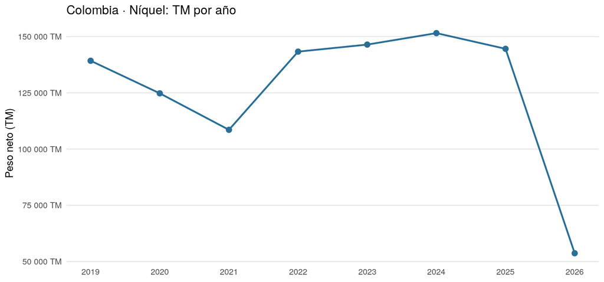

**FOB (USD)**

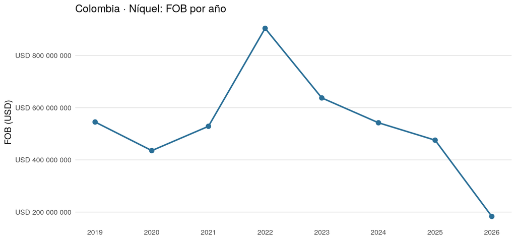

**Principales destinos**

**Todo el periodo**

| Destino | Peso neto | Porcentaje peso neto | FOB (USD) | Registros |
| --- | --- | --- | --- | --- |
| CHINA | 562 592,54 TM | 55,6% | USD 2 307,8 millones | 1 063 |
| PAÍSES BAJOS | 132 249,00 TM | 13,1% | USD 501,3 millones | 449 |
| COREA DEL SUR | 60 100,44 TM | 5,9% | USD 278,0 millones | 154 |
| JAPÓN | 54 120,95 TM | 5,3% | USD 240,1 millones | 377 |
| ALEMANIA | 35 129,63 TM | 3,5% | USD 132,2 millones | 152 |
| ITALIA | 33 227,38 TM | 3,3% | USD 164,9 millones | 70 |
| ESTADOS UNIDOS | 25 787,87 TM | 2,5% | USD 118,2 millones | 88 |
| ESPAÑA | 16 421,00 TM | 1,6% | USD 73,2 millones | 65 |
| HONG KONG | 15 358,64 TM | 1,5% | USD 62,4 millones | 43 |
| TAIWÁN, PROVINCIA DE CHINA | 15 081,31 TM | 1,5% | USD 67,7 millones | 58 |

**2025**

| Destino | Peso neto | Porcentaje peso neto | FOB (USD) | Registros |
| --- | --- | --- | --- | --- |
| CHINA | 82 059,80 TM | 56,8% | USD 274,1 millones | 165 |
| PAÍSES BAJOS | 26 930,17 TM | 18,6% | USD 78,4 millones | 79 |
| COREA DEL SUR | 8 700,74 TM | 6,0% | USD 29,7 millones | 27 |
| JAPÓN | 7 644,64 TM | 5,3% | USD 27,1 millones | 45 |
| ESPAÑA | 5 533,67 TM | 3,8% | USD 19,2 millones | 16 |
| ESTADOS UNIDOS | 4 498,77 TM | 3,1% | USD 16,1 millones | 15 |
| ITALIA | 4 412,74 TM | 3,1% | USD 14,0 millones | 10 |
| SUECIA | 2 544,48 TM | 1,8% | USD 9,1 millones | 15 |
| TAIWÁN, PROVINCIA DE CHINA | 1 286,29 TM | 0,9% | USD 4,8 millones | 5 |
| HONG KONG | 401,60 TM | 0,3% | USD 1,3 millones | 1 |

**Principales empresas exportadoras**

**Todo el periodo**

| Exportador | Peso neto | Porcentaje peso neto | FOB (USD) | Registros |
| --- | --- | --- | --- | --- |
| CERRO MATOSO SA | 1 011 990,53 TM | 100,0% | USD 4 251,2 millones | 2 739 |
| MOLDES MEDELLIN LTDA | 13,72 TM | 0,0% | USD 131 559 | 1 |
| C I ACA ALUMINIOS COBRES Y ACEROS S A S | 11,34 TM | 0,0% | USD 55 221 | 1 |
| TSO S.A.S | 10,52 TM | 0,0% | USD 22 | 1 |
| C I ALMASEG S A | 4,43 TM | 0,0% | USD 50 548 | 8 |
| QUIMICA INTL S A | 0,40 TM | 0,0% | USD 3 006 | 5 |

**2025**

| Exportador | Peso neto | Porcentaje peso neto | FOB (USD) | Registros |
| --- | --- | --- | --- | --- |
| CERRO MATOSO SA | 144 548,36 TM | 100,0% | USD 475,5 millones | 380 |
| QUIMICA INTL S A | 0,28 TM | 0,0% | USD 2 075 | 2 |

### Cobre

En el periodo, **Cobre** en **Colombia** suma 631 784,12 TM netas y USD 3 629,3 millones FOB (13 450 registros); en **2025**: 97 647,68 TM y USD 865,1 millones (1 865 registros).

**Evolución anual**

**Peso neto (TM)**

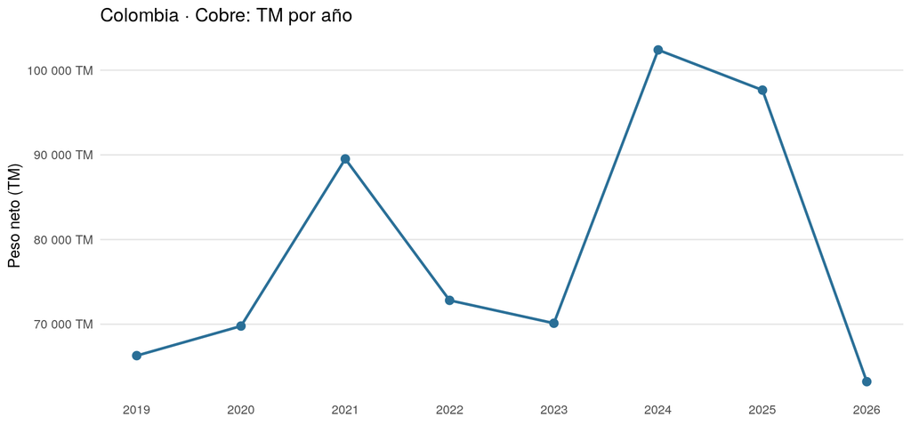

**FOB (USD)**

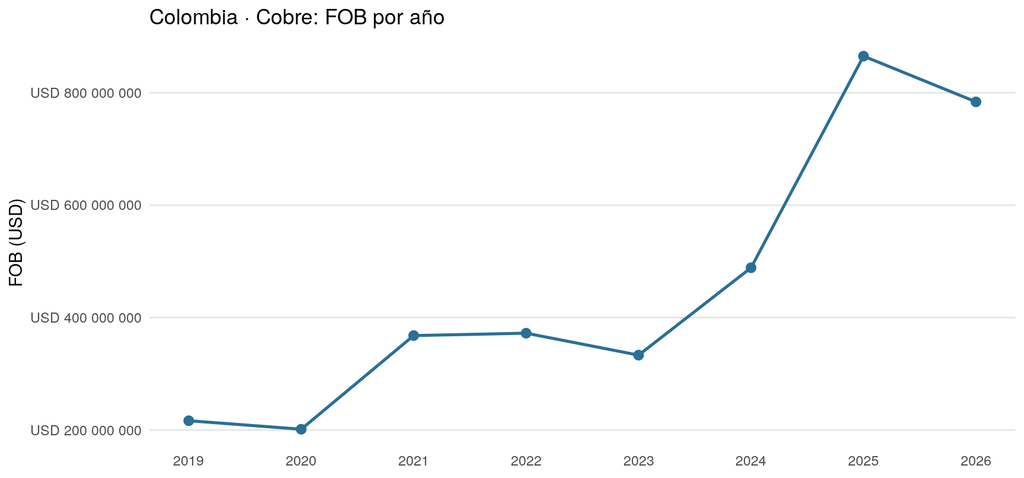

**Principales destinos**

**Todo el periodo**

| Destino | Peso neto | Porcentaje peso neto | FOB (USD) | Registros |
| --- | --- | --- | --- | --- |
| CHINA | 406 771,27 TM | 64,4% | USD 1 633,9 millones | 5 682 |
| COREA DEL SUR | 52 258,46 TM | 8,3% | USD 389,8 millones | 2 564 |
| PERÚ | 33 970,20 TM | 5,4% | USD 669,2 millones | 78 |
| INDIA | 33 157,97 TM | 5,2% | USD 188,7 millones | 888 |
| BRASIL | 19 521,20 TM | 3,1% | USD 133,2 millones | 787 |
| JAPÓN | 10 494,04 TM | 1,7% | USD 75,3 millones | 508 |
| MALASIA | 9 968,17 TM | 1,6% | USD 54,8 millones | 398 |
| HONG KONG | 9 432,05 TM | 1,5% | USD 46,9 millones | 401 |
| ZFP DEL CAUCA - (CENCAUCA) | 5 946,75 TM | 0,9% | USD 70,4 millones | 115 |
| GEORGIA | 5 363,10 TM | 0,8% | USD 80,7 millones | 7 |

**2025**

| Destino | Peso neto | Porcentaje peso neto | FOB (USD) | Registros |
| --- | --- | --- | --- | --- |
| CHINA | 57 261,70 TM | 58,6% | USD 377,9 millones | 1 062 |
| PERÚ | 14 360,31 TM | 14,7% | USD 255,7 millones | 21 |
| INDIA | 7 086,68 TM | 7,3% | USD 43,3 millones | 214 |
| GEORGIA | 4 524,53 TM | 4,6% | USD 68,3 millones | 6 |
| COREA DEL SUR | 4 074,09 TM | 4,2% | USD 37,1 millones | 221 |
| ZFP DEL CAUCA - (CENCAUCA) | 3 893,82 TM | 4,0% | USD 41,2 millones | 67 |
| MALASIA | 1 916,65 TM | 2,0% | USD 13,3 millones | 81 |
| TAILANDIA | 1 479,30 TM | 1,5% | USD 10,5 millones | 62 |
| JAPÓN | 596,11 TM | 0,6% | USD 4,9 millones | 23 |
| MÉXICO | 391,96 TM | 0,4% | USD 3,5 millones | 13 |

**Principales empresas exportadoras**

**Todo el periodo**

| Exportador | Peso neto | Porcentaje peso neto | FOB (USD) | Registros |
| --- | --- | --- | --- | --- |
| MINERA EL ROBLE S A | 271 891,17 TM | 43,0% | USD 492,4 millones | 34 |
| C I METALES LA UNION S A S | 67 837,88 TM | 10,7% | USD 482,6 millones | 2 123 |
| C I ACA ALUMINIOS COBRES Y ACEROS S A S | 66 212,48 TM | 10,5% | USD 513,4 millones | 3 357 |
| CONTINENTAL GOLD LIMITED | 45 523,65 TM | 7,2% | USD 894,1 millones | 46 |
| ATLANTICMETALS S A S | 34 396,49 TM | 5,4% | USD 247,7 millones | 1 669 |
| COMERCIALIZADORA INTL GREENMETAL S A S | 33 465,24 TM | 5,3% | USD 244,9 millones | 1 431 |
| CI INNOAMBIENTAL SAS | 15 089,50 TM | 2,4% | USD 120,6 millones | 682 |
| CONSORCIO OBRAS OPTIMIZACION DE RED | 8 554,41 TM | 1,4% | USD 48,9 millones | 154 |
| C I ALMASEG S A | 8 548,70 TM | 1,4% | USD 60,5 millones | 488 |
| CABLES DE ENERGIA Y DE TELECOMUNICACIONES S A | 7 814,97 TM | 1,2% | USD 88,2 millones | 154 |

**2025**

| Exportador | Peso neto | Porcentaje peso neto | FOB (USD) | Registros |
| --- | --- | --- | --- | --- |
| MINERA EL ROBLE S A | 25 476,12 TM | 26,1% | USD 54,9 millones | 3 |
| CONTINENTAL GOLD LIMITED | 25 108,54 TM | 25,7% | USD 443,7 millones | 27 |
| C I METALES LA UNION S A S | 12 212,93 TM | 12,5% | USD 97,2 millones | 396 |
| C I ACA ALUMINIOS COBRES Y ACEROS S A S | 10 041,70 TM | 10,3% | USD 82,8 millones | 519 |
| CABLES DE ENERGIA Y DE TELECOMUNICACIONES S A | 3 893,82 TM | 4,0% | USD 41,2 millones | 67 |
| ATLANTICMETALS S A S | 3 875,84 TM | 4,0% | USD 32,4 millones | 184 |
| COMERCIALIZADORA INTL GREENMETAL S A S | 3 576,14 TM | 3,7% | USD 29,4 millones | 153 |
| CI INNOAMBIENTAL SAS | 3 566,41 TM | 3,7% | USD 29,8 millones | 149 |
| CONSORCIO OBRAS OPTIMIZACION DE RED | 2 345,56 TM | 2,4% | USD 13,8 millones | 52 |
| COMERCIALIZADORA INTERNACIONAL SCRAPMETAL S.A.S. | 1 223,30 TM | 1,3% | USD 10,4 millones | 77 |

### Plata

En el periodo, **Plata** en **Colombia** suma 1 945,45 TM netas y USD 93,1 millones FOB (847 registros); en **2025**: 1 380,76 TM y USD 21,1 millones (256 registros).

**Evolución anual**

**Peso neto (TM)**

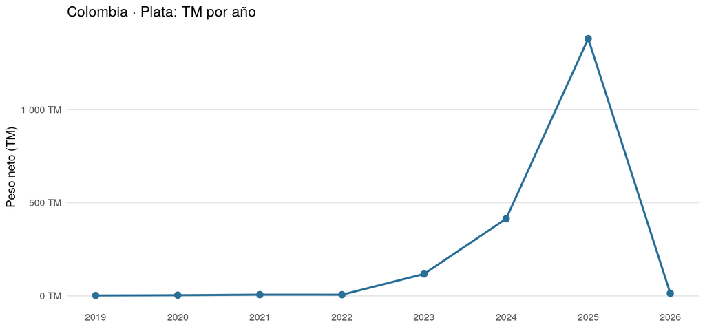

**FOB (USD)**

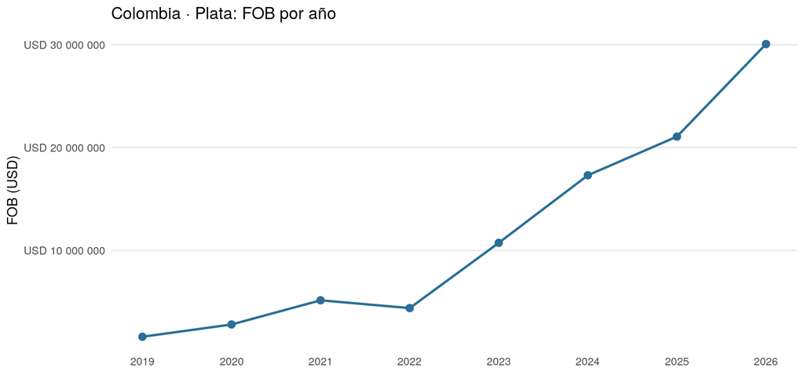

**Principales destinos**

**Todo el periodo**

| Destino | Peso neto | Porcentaje peso neto | FOB (USD) | Registros |
| --- | --- | --- | --- | --- |
| CHILE | 374,82 TM | 19,3% | USD 3,8 millones | 92 |
| BÉLGICA | 118,46 TM | 6,1% | USD 1,5 millones | 33 |
| ESTADOS UNIDOS | 42,59 TM | 2,2% | USD 46,1 millones | 198 |
| EMIRATOS ÁRABES UNIDOS | 13,02 TM | 0,7% | USD 19,4 millones | 158 |
| COREA DEL SUR | 6,91 TM | 0,4% | USD 4,8 millones | 22 |
| CHINA | 3,88 TM | 0,2% | USD 3,8 millones | 7 |
| AUSTRALIA | 3,55 TM | 0,2% | USD 2,3 millones | 18 |
| ZONA FRANCA RÍO NEGRO | 2,00 TM | 0,1% | USD 2,6 millones | 35 |
| TURQUÍA | 1,21 TM | 0,1% | USD 1,8 millones | 11 |
| PERÚ | 1,01 TM | 0,1% | USD 2,0 millones | 80 |

**2025**

| Destino | Peso neto | Porcentaje peso neto | FOB (USD) | Registros |
| --- | --- | --- | --- | --- |
| CHILE | 369,16 TM | 26,7% | USD 203 505 | 10 |
| BÉLGICA | 15,02 TM | 1,1% | USD 192 007 | 6 |
| ESTADOS UNIDOS | 7,64 TM | 0,6% | USD 8,8 millones | 41 |
| EMIRATOS ÁRABES UNIDOS | 4,91 TM | 0,4% | USD 6,1 millones | 50 |
| ZONA FRANCA RÍO NEGRO | 1,87 TM | 0,1% | USD 2,4 millones | 28 |
| URUGUAY | 1,34 TM | 0,1% | USD 266 300 | 30 |
| COREA DEL SUR | 0,99 TM | 0,1% | USD 881 353 | 3 |
| CHINA | 0,82 TM | 0,1% | USD 1,0 millones | 3 |
| TURQUÍA | 0,55 TM | 0,0% | USD 618 691 | 3 |
| SUIZA | 0,01 TM | 0,0% | USD 207 261 | 2 |

**Principales empresas exportadoras**

**Todo el periodo**

[output not shown]

**2025**

| Exportador | Peso neto | Porcentaje peso neto | FOB (USD) | Registros |
| --- | --- | --- | --- | --- |
| EGM COLOMBIA S.A.S. | 1 347,32 TM | 97,6% | USD 399 394 | 38 |
| ZANDOR CAPITAL S A COLOMBIA | 16,83 TM | 1,2% | USD 2,1 millones | 12 |
| LATRANS GRUPO LOGISTICO S A S | 6,94 TM | 0,5% | USD 8,1 millones | 30 |
| COMERCIALIZADORA INTL VALUE CO S A S | 3,63 TM | 0,3% | USD 4,5 millones | 38 |
| GEXGO S.A.S | 1,82 TM | 0,1% | USD 2,3 millones | 25 |
| YS MODA Y DISEÑOS SAS | 1,21 TM | 0,1% | USD 188 600 | 27 |
| C I GRUPO EXPORTADOR SAS | 0,85 TM | 0,1% | USD 1,1 millones | 8 |
| COMERCIALIZADORA A N JELL SAS | 0,83 TM | 0,1% | USD 996 159 | 5 |
| CIALZ INT DE MET PRECIOSOS Y MET COMUNES INV GENERALES S A | 0,79 TM | 0,1% | USD 715 640 | 5 |
| C I GOLD BY GOLD COLOMBIA SAS | 0,01 TM | 0,0% | USD 207 261 | 2 |

### Fosfato

En el periodo, **Fosfato** en **Colombia** suma 650,00 TM netas y USD 111 574 FOB (3 registros).

**Evolución anual**

**Peso neto (TM)**

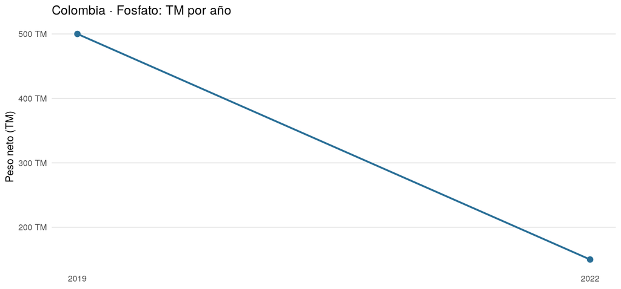

**FOB (USD)**

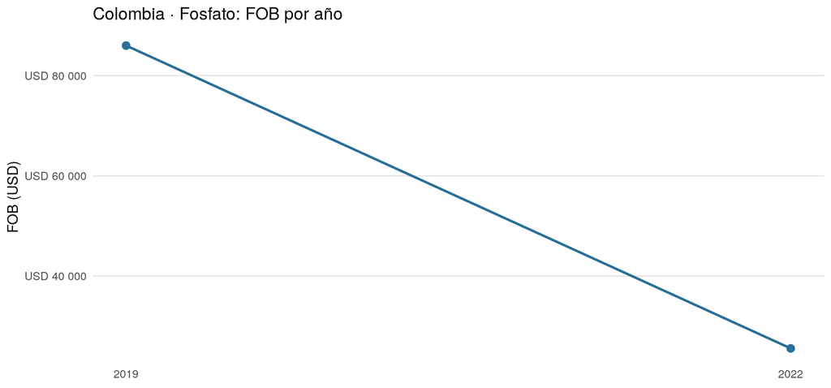

**Principales destinos**

**Todo el periodo**

| Destino | Peso neto | Porcentaje peso neto | FOB (USD) | Registros |
| --- | --- | --- | --- | --- |
| GUATEMALA | 650,00 TM | 100,0% | USD 111 574 | 3 |

**2025**

| Destino | Peso neto |
| --- | --- |
| — | — |

**Principales empresas exportadoras**

**Todo el periodo**

| Exportador | Peso neto | Porcentaje peso neto | FOB (USD) | Registros |
| --- | --- | --- | --- | --- |
| EMPRESA DE FOSFATOS DEL HUILA S.A. | 650,00 TM | 100,0% | USD 111 574 | 3 |

**2025**

| Exportador | Peso neto |
| --- | --- |
| — | — |

### Platino

En el periodo, **Platino** en **Colombia** suma 6,65 TM netas y USD 209,6 millones FOB (1 305 registros); en **2025**: 1,34 TM y USD 46,0 millones (304 registros).

**Evolución anual**

**Peso neto (TM)**

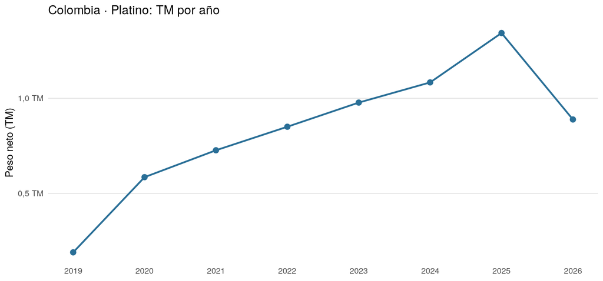

**FOB (USD)**

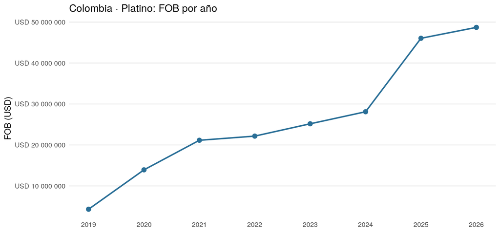

**Principales destinos**

**Todo el periodo**

| Destino | Peso neto | Porcentaje peso neto | FOB (USD) | Registros |
| --- | --- | --- | --- | --- |
| ESTADOS UNIDOS | 3,07 TM | 46,2% | USD 94,2 millones | 327 |
| ZONA FRANCA COLOMBIA | 1,35 TM | 20,3% | USD 34,1 millones | 511 |
| FRANCIA | 0,86 TM | 12,9% | USD 36,5 millones | 43 |
| ZONA FRANCA RÍO NEGRO | 0,72 TM | 10,9% | USD 27,4 millones | 368 |
| ITALIA | 0,32 TM | 4,8% | USD 8,4 millones | 34 |
| ALEMANIA | 0,21 TM | 3,2% | USD 5,8 millones | 11 |
| SUIZA | 0,07 TM | 1,1% | USD 2,0 millones | 6 |
| INDIA | 0,02 TM | 0,3% | USD 587 156 | 1 |
| SINGAPUR | 0,01 TM | 0,2% | USD 274 964 | 1 |
| HONG KONG | 0,01 TM | 0,1% | USD 238 976 | 1 |

**2025**

| Destino | Peso neto | Porcentaje peso neto | FOB (USD) | Registros |
| --- | --- | --- | --- | --- |
| ESTADOS UNIDOS | 0,59 TM | 43,9% | USD 21,7 millones | 59 |
| ZONA FRANCA RÍO NEGRO | 0,55 TM | 41,1% | USD 18,9 millones | 231 |
| FRANCIA | 0,18 TM | 13,4% | USD 4,8 millones | 12 |
| ALEMANIA | 0,02 TM | 1,1% | USD 357 181 | 1 |
| ITALIA | 0,01 TM | 0,4% | USD 267 925 | 1 |

**Principales empresas exportadoras**

**Todo el periodo**

| Exportador | Peso neto | Porcentaje peso neto | FOB (USD) | Registros |
| --- | --- | --- | --- | --- |
| SUMITRADE SAS | 1,38 TM | 20,8% | USD 36,7 millones | 74 |
| COMERCIALIZADORA INTL ESLOP S A S | 1,34 TM | 20,1% | USD 59,0 millones | 61 |
| INVERSIONES FENIX 2 SAS | 0,89 TM | 13,5% | USD 22,5 millones | 181 |
| EL MOHÁN DE QUITO S.A.S. | 0,65 TM | 9,8% | USD 23,1 millones | 210 |
| SOC DE COMERCIALIZACION INTL ANTIOQUENA DE EXP | 0,50 TM | 7,5% | USD 14,0 millones | 44 |
| C I GRUPO EXPORTADOR SAS | 0,28 TM | 4,2% | USD 8,2 millones | 18 |
| C I DE METALES PRECIOSOS DE COLOMBIA S A | 0,16 TM | 2,4% | USD 3,8 millones | 19 |
| C.I ARANY S.A.S. | 0,12 TM | 1,9% | USD 4,3 millones | 20 |
| GRUPO EMPRESARIAL MONTE DORADO S.A.S | 0,12 TM | 1,8% | USD 3,6 millones | 37 |
| ALQUIMIA INVESTMENTS S.A.S. | 0,08 TM | 1,1% | USD 3,5 millones | 71 |

**2025**

| Exportador | Peso neto | Porcentaje peso neto | FOB (USD) | Registros |
| --- | --- | --- | --- | --- |
| COMERCIALIZADORA INTL ESLOP S A S | 0,54 TM | 40,3% | USD 19,4 millones | 22 |
| EL MOHÁN DE QUITO S.A.S. | 0,46 TM | 34,0% | USD 15,3 millones | 111 |
| C.I ARANY S.A.S. | 0,10 TM | 7,6% | USD 3,3 millones | 16 |
| C I GRUPO EXPORTADOR SAS | 0,04 TM | 3,1% | USD 1,2 millones | 3 |
| COMERCIALIZADORA A N JELL SAS | 0,03 TM | 2,4% | USD 760 131 | 2 |
| CONSEJO COMUNITARIO MAYOR DE CONDOTO - IRO | 0,03 TM | 2,1% | USD 900 108 | 62 |
| GRUPO EMPRESARIAL MONTE DORADO S.A.S | 0,02 TM | 1,8% | USD 905 560 | 19 |
| COMERCIALIZADORA INTERNACIONAL COLTIC SAS | 0,02 TM | 1,6% | USD 602 003 | 10 |
| ALQUIMIA INVESTMENTS S.A.S. | 0,02 TM | 1,6% | USD 901 151 | 28 |
| 42 ENTERPRISES SAS | 0,02 TM | 1,2% | USD 651 613 | 4 |

## Exportaciones · Ecuador

| Mineral | Peso neto | Porcentaje peso neto | FOB (USD) | Registros |
| --- | --- | --- | --- | --- |
| Cobre | 1 622 676,31 TM | 99,8% | USD 10 234,4 millones | 8 368 |
| Baritina | 2 157,89 TM | 0,1% | USD 686 315 | 32 |
| Plata | 1 301,21 TM | 0,1% | USD 9,5 millones | 103 |

**Principales destinos**

**Todo el periodo**

| Destino | Peso neto | Porcentaje peso neto | FOB (USD) | Registros |
| --- | --- | --- | --- | --- |
| CHINA | 1 338 317,14 TM | 82,3% | USD 9 162,1 millones | 3 354 |
| PERÚ | 192 352,78 TM | 11,8% | USD 588,9 millones | 1 587 |
| COREA DEL SUR | 31 387,39 TM | 1,9% | USD 193,2 millones | 1 378 |
| MÉXICO | 22 858,17 TM | 1,4% | USD 60,0 millones | 166 |
| BRASIL | 8 241,70 TM | 0,5% | USD 60,0 millones | 276 |
| JAPÓN | 4 001,96 TM | 0,2% | USD 31,2 millones | 182 |
| HONG KONG | 2 912,82 TM | 0,2% | USD 14,5 millones | 154 |
| ALEMANIA | 2 629,09 TM | 0,2% | USD 12,2 millones | 81 |
| ESTADOS UNIDOS | 2 231,58 TM | 0,1% | USD 17,5 millones | 333 |
| PAÍSES NO DECLARADOS | 0,74 TM | 0,0% | USD 14,5 millones | 23 |

**2025**

| Destino | Peso neto | Porcentaje peso neto | FOB (USD) | Registros |
| --- | --- | --- | --- | --- |
| CHINA | 723 772,19 TM | 95,5% | USD 1 995,3 millones | 697 |
| PERÚ | 28 222,78 TM | 3,7% | USD 104,9 millones | 231 |
| COREA DEL SUR | 2 210,82 TM | 0,3% | USD 19,3 millones | 109 |
| INDIA | 1 036,68 TM | 0,1% | USD 4,3 millones | 92 |
| BRASIL | 839,05 TM | 0,1% | USD 7,5 millones | 29 |
| TAILANDIA | 416,89 TM | 0,1% | USD 3,1 millones | 25 |
| JAPÓN | 365,50 TM | 0,0% | USD 3,2 millones | 14 |
| ESTADOS UNIDOS | 178,38 TM | 0,0% | USD 1,9 millones | 34 |
| TAIWÁN, PROVINCIA DE CHINA | 149,58 TM | 0,0% | USD 1,1 millones | 8 |
| PAÍSES NO DECLARADOS | 0,29 TM | 0,0% | USD 9,4 millones | 9 |

### Cobre

En el periodo, **Cobre** en **Ecuador** suma 1 622 676,31 TM netas y USD 10 234,4 millones FOB (8 368 registros); en **2025**: 757 460,28 TM y USD 2 149,6 millones (1 276 registros).

**Evolución anual**

**Peso neto (TM)**

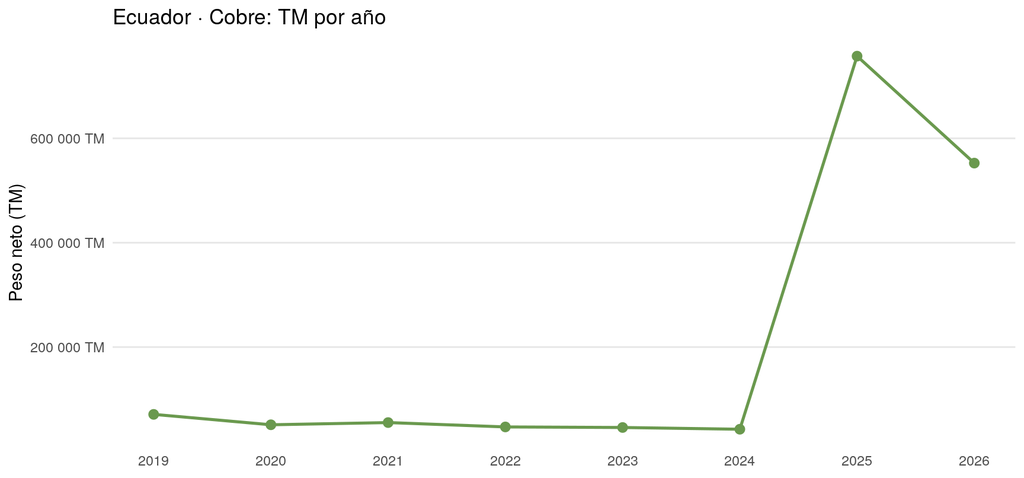

**FOB (USD)**

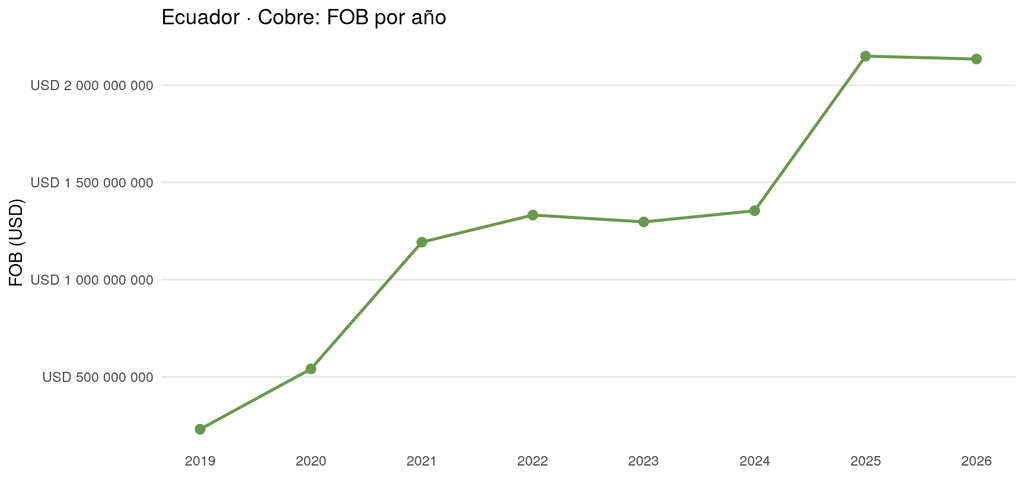

**Principales destinos**

**Todo el periodo**

| Destino | Peso neto | Porcentaje peso neto | FOB (USD) | Registros |
| --- | --- | --- | --- | --- |
| CHINA | 1 337 378,16 TM | 82,4% | USD 9 160,3 millones | 3 348 |
| PERÚ | 192 118,87 TM | 11,8% | USD 588,4 millones | 1 582 |
| COREA DEL SUR | 31 387,39 TM | 1,9% | USD 193,2 millones | 1 378 |
| MÉXICO | 22 858,17 TM | 1,4% | USD 60,0 millones | 166 |
| BRASIL | 8 241,70 TM | 0,5% | USD 60,0 millones | 275 |
| JAPÓN | 4 001,96 TM | 0,2% | USD 31,2 millones | 182 |
| HONG KONG | 2 912,82 TM | 0,2% | USD 14,5 millones | 154 |
| ALEMANIA | 2 629,09 TM | 0,2% | USD 12,2 millones | 81 |
| ESTADOS UNIDOS | 2 225,47 TM | 0,1% | USD 14,3 millones | 283 |
| PAÍSES NO DECLARADOS | 0,74 TM | 0,0% | USD 13,6 millones | 20 |

**2025**

| Destino | Peso neto | Porcentaje peso neto | FOB (USD) | Registros |
| --- | --- | --- | --- | --- |
| CHINA | 723 671,02 TM | 95,5% | USD 1 994,6 millones | 695 |
| PERÚ | 28 108,26 TM | 3,7% | USD 104,7 millones | 230 |
| COREA DEL SUR | 2 210,82 TM | 0,3% | USD 19,3 millones | 109 |
| INDIA | 1 036,68 TM | 0,1% | USD 4,3 millones | 92 |
| BRASIL | 839,05 TM | 0,1% | USD 7,5 millones | 29 |
| TAILANDIA | 416,89 TM | 0,1% | USD 3,1 millones | 25 |
| JAPÓN | 365,50 TM | 0,0% | USD 3,2 millones | 14 |
| ESTADOS UNIDOS | 177,60 TM | 0,0% | USD 1,2 millones | 27 |
| TAIWÁN, PROVINCIA DE CHINA | 149,58 TM | 0,0% | USD 1,1 millones | 8 |
| PAÍSES NO DECLARADOS | 0,29 TM | 0,0% | USD 8,4 millones | 7 |

**Principales empresas exportadoras**

**Todo el periodo**

| Exportador | Peso neto | Porcentaje peso neto | FOB (USD) | Registros |
| --- | --- | --- | --- | --- |
| ECUACORRIENTE S.A. | 1 234 340,61 TM | 76,1% | USD 8 568,8 millones | 183 |
| METALKING S.A. | 48 628,01 TM | 3,0% | USD 378,2 millones | 3 231 |
| PRACTIPOWER S.A. | 43 859,45 TM | 2,7% | USD 284,4 millones | 1 669 |
| MINERA ORO ALIANZA ALLIANCEGOLD S A | 34 699,30 TM | 2,1% | USD 74,0 millones | 247 |
| SOCIEDAD CIVIL MINERA GOLDMINS | 23 852,99 TM | 1,5% | USD 77,0 millones | 123 |
| FUNDAMETZ S.A. | 19 997,29 TM | 1,2% | USD 140,5 millones | 308 |
| OROCORMINA CIA LTDA | 18 479,17 TM | 1,1% | USD 58,5 millones | 115 |
| BLACIO TINOCO ANGEL JORGE | 17 881,16 TM | 1,1% | USD 50,8 millones | 168 |
| OROCONCENT S A | 14 037,11 TM | 0,9% | USD 58,9 millones | 112 |
| GOLDMINING S.A. | 9 919,07 TM | 0,6% | USD 51,7 millones | 56 |

**2025**

| Exportador | Peso neto | Porcentaje peso neto | FOB (USD) | Registros |
| --- | --- | --- | --- | --- |
| ECUACORRIENTE S.A. | 707 063,44 TM | 93,3% | USD 1 892,2 millones | 28 |
| METALKING S.A. | 7 411,36 TM | 1,0% | USD 59,2 millones | 596 |
| PRACTIPOWER S.A. | 5 134,31 TM | 0,7% | USD 44,2 millones | 210 |
| OROCONCENT S A | 4 938,15 TM | 0,7% | USD 17,4 millones | 27 |
| OROCORMINA CIA LTDA | 4 358,82 TM | 0,6% | USD 16,4 millones | 25 |
| SOCIEDAD CIVIL MINERA GOLDMINS | 3 227,08 TM | 0,4% | USD 12,5 millones | 11 |
| BLACIO TINOCO ANGEL JORGE | 2 676,71 TM | 0,4% | USD 11,1 millones | 31 |
| ROMERO LOAIZA JOSE MIGUEL | 1 702,84 TM | 0,2% | USD 7,4 millones | 15 |
| ECUAPETSA PET DEL ECUADOR S.A. | 1 070,58 TM | 0,1% | USD 9,3 millones | 53 |
| FUNDAMETZ S.A. | 1 064,14 TM | 0,1% | USD 7,0 millones | 27 |

### Baritina

En el periodo, **Baritina** en **Ecuador** suma 2 157,89 TM netas y USD 686 315 FOB (32 registros); en **2025**: 373,39 TM y USD 119 284 (6 registros).

**Evolución anual**

**Peso neto (TM)**

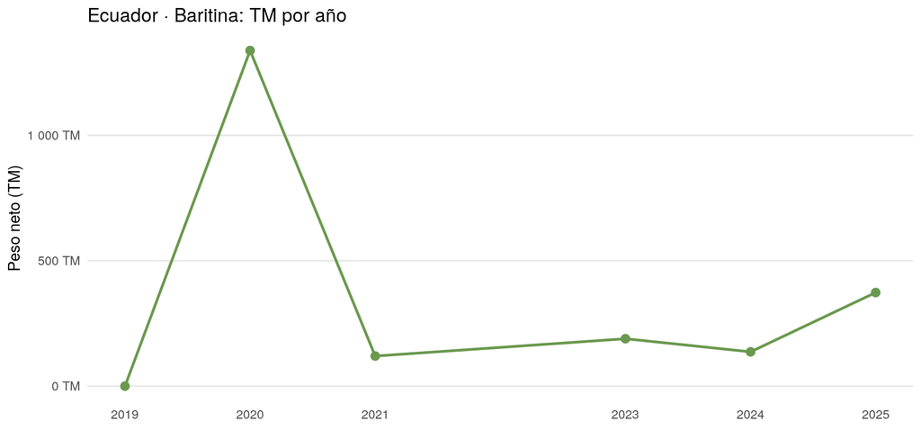

**FOB (USD)**

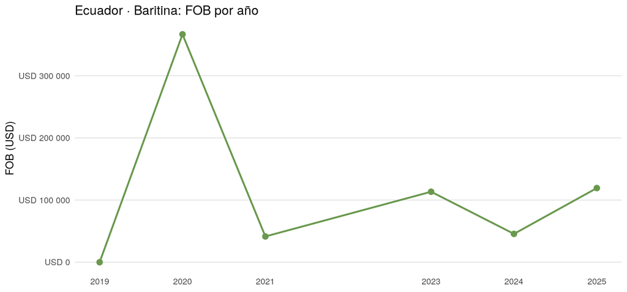

**Principales destinos**

**Todo el periodo**

| Destino | Peso neto | Porcentaje peso neto | FOB (USD) | Registros |
| --- | --- | --- | --- | --- |
| GUYANA | 1 338,68 TM | 62,0% | USD 366 631 | 19 |
| COLOMBIA | 819,21 TM | 38,0% | USD 314 190 | 10 |
| BRASIL | 0,00 TM | 0,0% | USD 33 | 1 |
| PAÍSES NO DECLARADOS | 0,00 TM | 0,0% | USD 5 460 | 1 |
| CHINA | 0,00 TM | 0,0% | USD 2 | 1 |

**2025**

| Destino | Peso neto | Porcentaje peso neto | FOB (USD) | Registros |
| --- | --- | --- | --- | --- |
| COLOMBIA | 373,39 TM | 100,0% | USD 113 824 | 5 |
| PAÍSES NO DECLARADOS | 0,00 TM | 0,0% | USD 5 460 | 1 |

**Principales empresas exportadoras**

**Todo el periodo**

| Exportador | Peso neto | Porcentaje peso neto | FOB (USD) | Registros |
| --- | --- | --- | --- | --- |
| SCHLUMBERGER DEL ECUADOR S.A. | 1 608,82 TM | 74,6% | USD 457 709 | 23 |
| JEBSEN & JESSEN ECUADOR S. A. | 360,00 TM | 16,7% | USD 109 730 | 4 |
| BAKER HUGHES SERVICES INTERNATIONAL S.A.S | 189,07 TM | 8,8% | USD 113 381 | 2 |
| HALLIBURTON LATIN AMERICA S.R.L. | 0,00 TM | 0,0% | USD 33 | 1 |
| EGAR SA | 0,00 TM | 0,0% | USD 5 460 | 1 |
| CAMPOTRACK S.A. | 0,00 TM | 0,0% | USD 2 | 1 |

**2025**

| Exportador | Peso neto | Porcentaje peso neto | FOB (USD) | Registros |
| --- | --- | --- | --- | --- |
| JEBSEN & JESSEN ECUADOR S. A. | 360,00 TM | 96,4% | USD 109 730 | 4 |
| SCHLUMBERGER DEL ECUADOR S.A. | 13,39 TM | 3,6% | USD 4 094 | 1 |
| EGAR SA | 0,00 TM | 0,0% | USD 5 460 | 1 |

### Plata

En el periodo, **Plata** en **Ecuador** suma 1 301,21 TM netas y USD 9,5 millones FOB (103 registros); en **2025**: 336,96 TM y USD 3,2 millones (28 registros).

**Evolución anual**

**Peso neto (TM)**

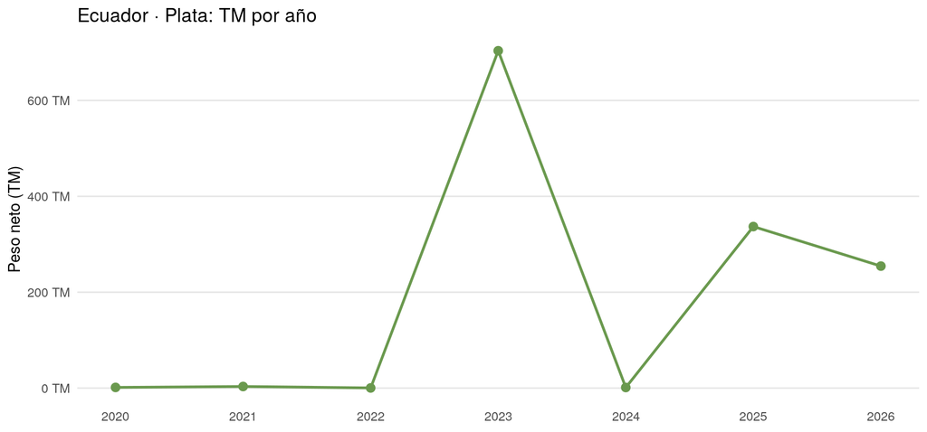

**FOB (USD)**

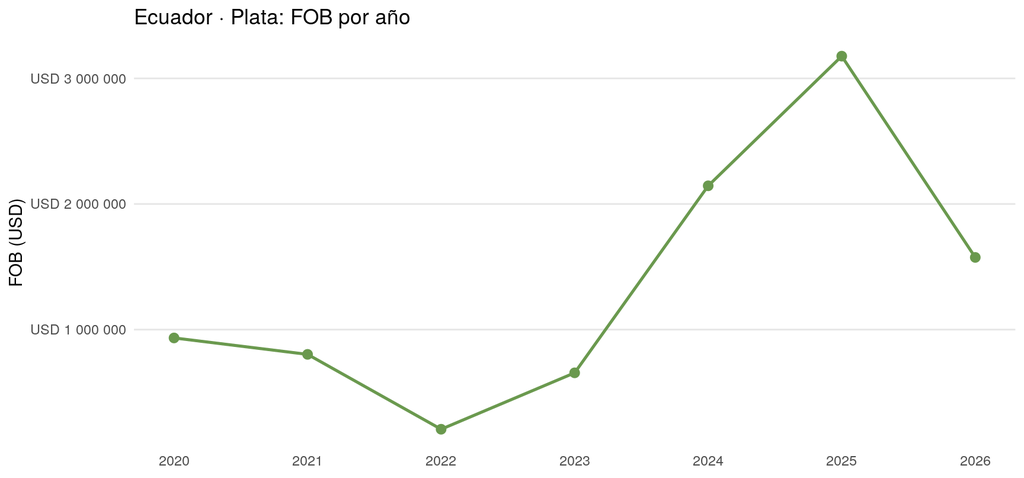

**Principales destinos**

**Todo el periodo**

| Destino | Peso neto | Porcentaje peso neto | FOB (USD) | Registros |
| --- | --- | --- | --- | --- |
| CHINA | 938,98 TM | 72,2% | USD 1,8 millones | 5 |
| PERÚ | 233,91 TM | 18,0% | USD 504 301 | 5 |
| EMIRATOS ÁRABES UNIDOS | 121,87 TM | 9,4% | USD 2,7 millones | 36 |
| ESTADOS UNIDOS | 6,10 TM | 0,5% | USD 3,2 millones | 50 |
| INDIA | 0,22 TM | 0,0% | USD 148 974 | 2 |
| REPÚBLICA DOMINICANA | 0,08 TM | 0,0% | USD 82 439 | 2 |
| PANAMÁ | 0,04 TM | 0,0% | USD 21 000 | 1 |
| PAÍSES NO DECLARADOS | 0,00 TM | 0,0% | USD 940 902 | 2 |

**2025**

| Destino | Peso neto | Porcentaje peso neto | FOB (USD) | Registros |
| --- | --- | --- | --- | --- |
| EMIRATOS ÁRABES UNIDOS | 120,49 TM | 35,8% | USD 591 972 | 17 |
| PERÚ | 114,52 TM | 34,0% | USD 192 857 | 1 |
| CHINA | 101,17 TM | 30,0% | USD 711 073 | 2 |
| ESTADOS UNIDOS | 0,78 TM | 0,2% | USD 740 702 | 7 |
| PAÍSES NO DECLARADOS | 0,00 TM | 0,0% | USD 940 529 | 1 |

**Principales empresas exportadoras**

**Todo el periodo**

[output not shown]

**2025**

| Exportador | Peso neto | Porcentaje peso neto | FOB (USD) | Registros |
| --- | --- | --- | --- | --- |
| GONZALEZ CORDOVA JIMMY BRYAN | 120,00 TM | 35,6% | USD 105 840 | 2 |
| ECUMINERALES S A | 114,52 TM | 34,0% | USD 192 857 | 1 |
| COMPAÃ‘IA MINERA SOMIBER S.A. | 101,17 TM | 30,0% | USD 711 073 | 2 |
| ROMERO LEON EDWIN IVAN | 0,67 TM | 0,2% | USD 621 463 | 6 |
| ALBERCA AVILA LIONARDO | 0,18 TM | 0,1% | USD 186 286 | 7 |
| SEVERINO CORDOVA MARLON FABRICIO | 0,13 TM | 0,0% | USD 114 660 | 3 |
| METAL CORP S&T S.A. | 0,11 TM | 0,0% | USD 119 238 | 1 |
| TINOCO TINOCO JUAN PABLO | 0,10 TM | 0,0% | USD 99 392 | 3 |
| JP-METAL S.A.S. | 0,08 TM | 0,0% | USD 85 795 | 2 |
| CMA-CGM ECUADOR S.A. | 0,00 TM | 0,0% | USD 940 529 | 1 |

# Exportaciones a Estados Unidos

Subset con destino Veritrade **ESTADOS UNIDOS**. Son **19 668** registros: **24 570 639,34 TM** netas y **USD 52 688,7 millones** FOB (10,6% del tonelaje Latam del scrape; 8,8% del FOB).

No hay ranking de destinos (el destino es EE.UU.); el detalle por mineral muestra evolución TM/FOB y **exportadoras** hacia ese mercado (tabs periodo / 2025).

| País | Peso neto | Porcentaje peso neto | FOB a EE.UU. | Registros | Periodo |
| --- | --- | --- | --- | --- | --- |
| Peru | 19 966 953,51 TM | 18,6% | USD 9 094,5 millones | 5 285 | 2019–2026 |
| Chile | 4 570 929,92 TM | 3,8% | USD 43 291,4 millones | 13 154 | 2019–2026 |
| Colombia | 30 524,34 TM | 1,9% | USD 285,3 millones | 896 | 2019–2026 |
| Ecuador | 2 231,58 TM | 0,1% | USD 17,5 millones | 333 | 2019–2026 |

## Evolución anual hacia EE.UU.

**Peso neto (TM)**

[interactive chart not shown]

**FOB (USD)**

[interactive chart not shown]

## A EE.UU. · Peru

En la tabla, **Porcentaje peso neto** es la participación de cada mineral en el tonelaje de este país hacia EE.UU. **Porcentaje de todo exportado** (columna sombreada) es el peso neto (TM) enviado a EE.UU. de ese mineral dividido entre el peso neto del mismo mineral exportado a **todos** los destinos en el scrape. Ejemplo: si Perú exporta 412 396 TM de cobre a EE.UU., la columna sombreada dice qué fracción son de todo el cobre peruano exportado (todos los países).

| Mineral | Peso neto | Porcentaje peso neto | FOB (USD) | Porcentaje de todo exportado | Registros |
| --- | --- | --- | --- | --- | --- |
| Fosfato | 19 462 508,03 TM | 97,5% | USD 1 944,6 millones | 63,8% | 402 |
| Cobre | 412 396,03 TM | 2,1% | USD 4 057,9 millones | 0,6% | 1 827 |
| Estaño | 80 886,71 TM | 0,4% | USD 2 508,2 millones | 40,6% | 2 009 |
| Plomo | 8 418,26 TM | 0,0% | USD 17,5 millones | 0,2% | 301 |
| Plata | 2 704,45 TM | 0,0% | USD 566,2 millones | 0,1% | 744 |
| Arsénico | 40,00 TM | 0,0% | USD 82 480 | 100,0% | 1 |
| Baritina | 0,03 TM | 0,0% | USD 105 | 0,0% | 1 |

### Fosfato (a EE.UU.)

Hacia Estados Unidos, **Fosfato** desde **Peru** suma 19 462 508,03 TM netas y USD 1 944,6 millones FOB (402 registros); eso es el **63,8%** del tonelaje de Fosfato exportado a todos los destinos; en **2025**: 3 325 988,26 TM y USD 294,6 millones (62 registros).

**Evolución anual hacia EE.UU.**

**Peso neto (TM)**

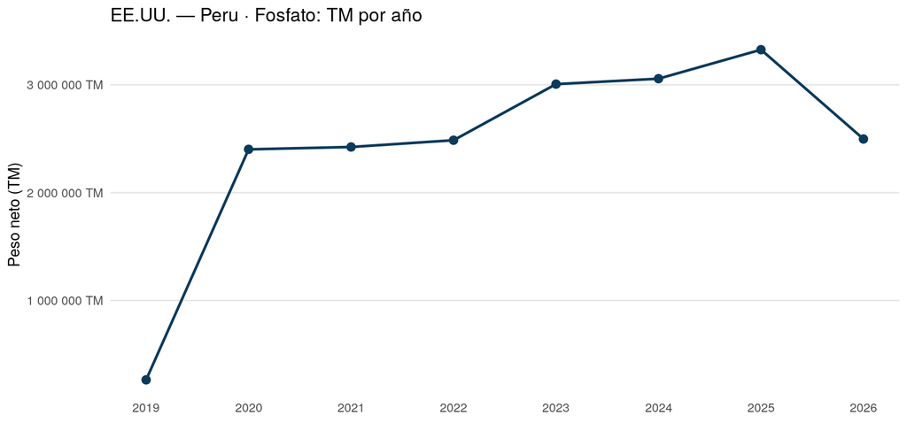

**FOB (USD)**

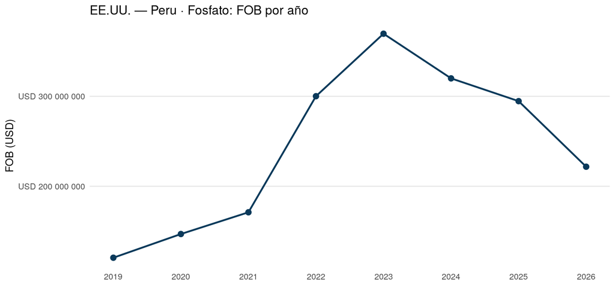

**Principales empresas exportadoras (destino EE.UU.)**

**Todo el periodo**

| Exportador | Peso neto | Porcentaje peso neto | FOB (USD) | Registros |
| --- | --- | --- | --- | --- |
| COMPAÑIA MINERA MISKI MAYO S.R.L. | 19 462 507,26 TM | 100,0% | USD 1 944,6 millones | 400 |
| SOCIEDAD MINERA CERRO VERDE S.A.A. | 0,76 TM | 0,0% | USD 360 | 2 |

**2025**

| Exportador | Peso neto | Porcentaje peso neto | FOB (USD) | Registros |
| --- | --- | --- | --- | --- |
| COMPAÑIA MINERA MISKI MAYO S.R.L. | 3 325 988,26 TM | 100,0% | USD 294,6 millones | 62 |

### Cobre (a EE.UU.)

Hacia Estados Unidos, **Cobre** desde **Peru** suma 412 396,03 TM netas y USD 4 057,9 millones FOB (1 827 registros); eso es el **0,6%** del tonelaje de Cobre exportado a todos los destinos; en **2025**: 58 417,84 TM y USD 610,9 millones (303 registros).

**Evolución anual hacia EE.UU.**

**Peso neto (TM)**

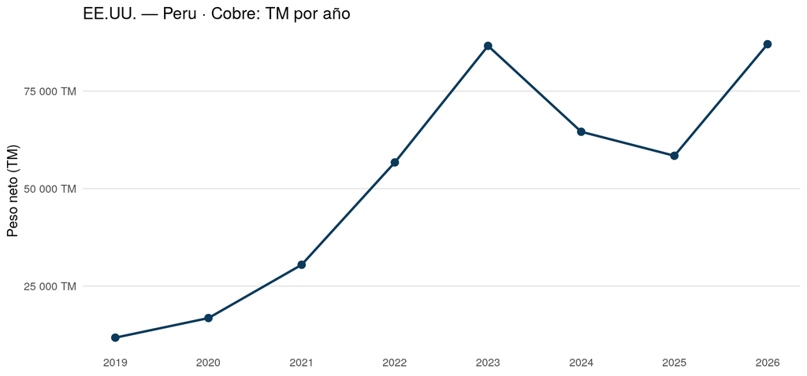

**FOB (USD)**

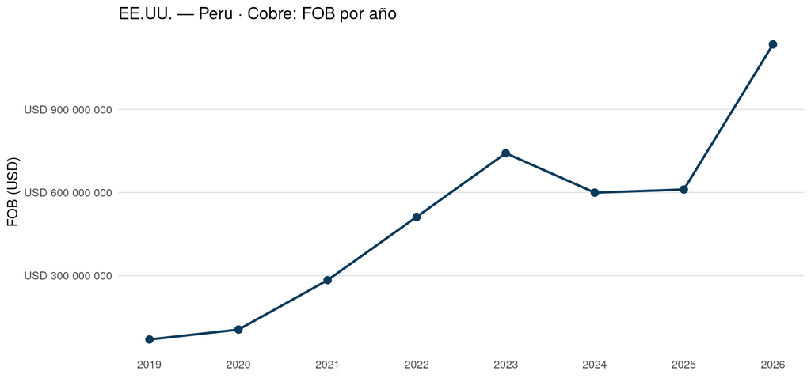

**Principales empresas exportadoras (destino EE.UU.)**

**Todo el periodo**

| Exportador | Peso neto | Porcentaje peso neto | FOB (USD) | Registros |
| --- | --- | --- | --- | --- |
| SOUTHERN PERU COPPER CORPORATION, SUCURSAL DEL PERÚ | 274 120,98 TM | 66,5% | USD 2 673,3 millones | 470 |
| SOCIEDAD MINERA CERRO VERDE S.A.A. | 93 401,06 TM | 22,6% | USD 924,9 millones | 142 |
| TECNOFIL S A | 16 559,21 TM | 4,0% | USD 158,1 millones | 973 |
| MARCOBRE S.A.C. | 14 371,32 TM | 3,5% | USD 145,8 millones | 51 |
| COMPAÑIA MINERA ANTAPACCAY S.A. | 6 816,40 TM | 1,7% | USD 86,2 millones | 18 |
| TRAFIGURA PERU SOCIEDAD ANONIMA CERRADA - TRAFIGURA PERU S.A.C. | 1 638,72 TM | 0,4% | USD 19,7 millones | 7 |
| MINERA PAMPA DE COBRE S.A.C. | 1 502,16 TM | 0,4% | USD 21,6 millones | 23 |
| GLENCORE PERU S.A.C. | 713,70 TM | 0,2% | USD 7,6 millones | 1 |
| IXM TRADING PERU S.A.C. | 515,37 TM | 0,1% | USD 6,3 millones | 1 |
| INDECO S.A. | 297,58 TM | 0,1% | USD 3,6 millones | 3 |

**2025**

| Exportador | Peso neto | Porcentaje peso neto | FOB (USD) | Registros |
| --- | --- | --- | --- | --- |
| SOUTHERN PERU COPPER CORPORATION, SUCURSAL DEL PERÚ | 35 467,04 TM | 60,7% | USD 372,2 millones | 59 |
| SOCIEDAD MINERA CERRO VERDE S.A.A. | 7 308,92 TM | 12,5% | USD 74,4 millones | 14 |
| MARCOBRE S.A.C. | 7 303,03 TM | 12,5% | USD 77,5 millones | 24 |
| TECNOFIL S A | 4 081,02 TM | 7,0% | USD 43,0 millones | 188 |
| COMPAÑIA MINERA ANTAPACCAY S.A. | 1 802,78 TM | 3,1% | USD 21,4 millones | 2 |
| TRAFIGURA PERU SOCIEDAD ANONIMA CERRADA - TRAFIGURA PERU S.A.C. | 1 614,43 TM | 2,8% | USD 19,4 millones | 6 |
| ZHAOSUN TRADING S.A.C. | 589,10 TM | 1,0% | USD 770 597 | 1 |
| INDECO S.A. | 188,87 TM | 0,3% | USD 1,9 millones | 2 |
| ALESSI INDUSTRIAL MINERO EIRL | 21,07 TM | 0,0% | USD 116 703 | 1 |
| RECOLEC RAMBISHO E.I.R.L. | 20,46 TM | 0,0% | USD 113 324 | 1 |

### Estaño (a EE.UU.)

Hacia Estados Unidos, **Estaño** desde **Peru** suma 80 886,71 TM netas y USD 2 508,2 millones FOB (2 009 registros); eso es el **40,6%** del tonelaje de Estaño exportado a todos los destinos; en **2025**: 12 970,39 TM y USD 462,5 millones (346 registros).

**Evolución anual hacia EE.UU.**

**Peso neto (TM)**

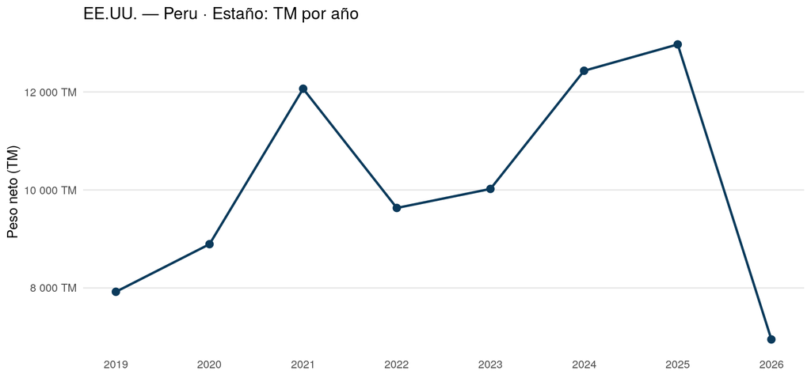

**FOB (USD)**

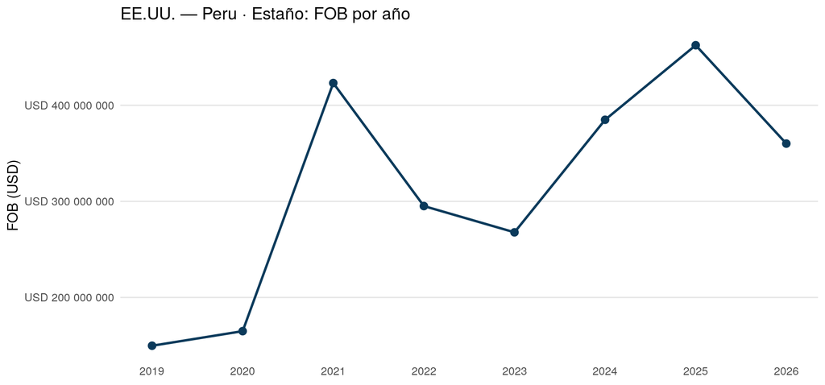

**Principales empresas exportadoras (destino EE.UU.)**

**Todo el periodo**

| Exportador | Peso neto | Porcentaje peso neto | FOB (USD) | Registros |
| --- | --- | --- | --- | --- |
| MINSUR S. A. | 80 875,35 TM | 100,0% | USD 2 508,1 millones | 2 006 |
| ZINC INDUSTRIAS NACIONALES S A | 11,37 TM | 0,0% | USD 105 284 | 3 |

**2025**

| Exportador | Peso neto | Porcentaje peso neto | FOB (USD) | Registros |
| --- | --- | --- | --- | --- |
| MINSUR S. A. | 12 970,39 TM | 100,0% | USD 462,5 millones | 346 |

### Plomo (a EE.UU.)

Hacia Estados Unidos, **Plomo** desde **Peru** suma 8 418,26 TM netas y USD 17,5 millones FOB (301 registros); eso es el **0,2%** del tonelaje de Plomo exportado a todos los destinos; en **2025**: 497,29 TM y USD 987 873 (14 registros).

**Evolución anual hacia EE.UU.**

**Peso neto (TM)**

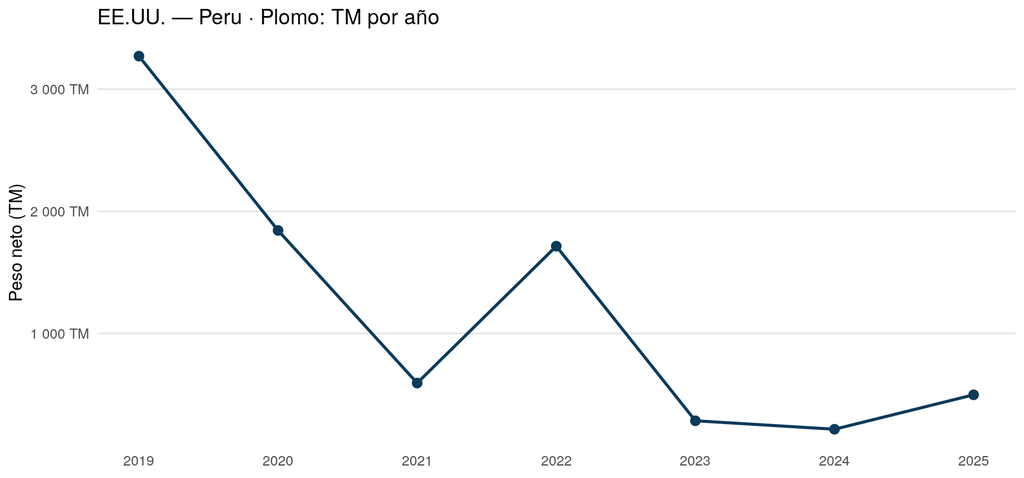

**FOB (USD)**

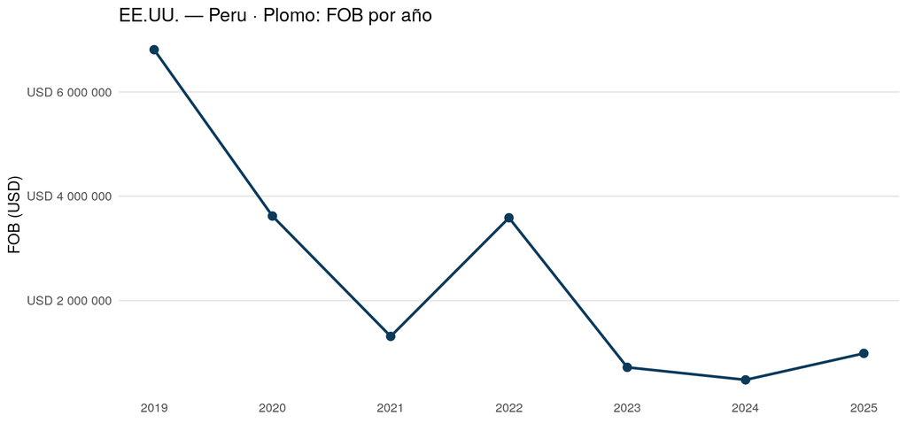

**Principales empresas exportadoras (destino EE.UU.)**

**Todo el periodo**

| Exportador | Peso neto | Porcentaje peso neto | FOB (USD) | Registros |
| --- | --- | --- | --- | --- |
| ZINC INDUSTRIAS NACIONALES S A | 7 175,58 TM | 85,2% | USD 15,3 millones | 72 |
| SYNERGYA S.A.C. | 643,87 TM | 7,6% | USD 1,0 millones | 208 |
| INDUSTRIAL SURQUILLO S.A.C. | 249,62 TM | 3,0% | USD 516 207 | 7 |
| ECOFUSION HUACRE E.I.R.L. | 199,69 TM | 2,4% | USD 381 612 | 8 |
| RECIPERU GROUP E.I.R.L. | 99,20 TM | 1,2% | USD 187 556 | 4 |
| EXPO METALES PERU E.I.R.L. | 50,30 TM | 0,6% | USD 97 401 | 2 |

**2025**

| Exportador | Peso neto | Porcentaje peso neto | FOB (USD) | Registros |
| --- | --- | --- | --- | --- |
| INDUSTRIAL SURQUILLO S.A.C. | 247,30 TM | 49,7% | USD 508 860 | 4 |
| ECOFUSION HUACRE E.I.R.L. | 199,69 TM | 40,2% | USD 381 612 | 8 |
| EXPO METALES PERU E.I.R.L. | 50,30 TM | 10,1% | USD 97 401 | 2 |

### Plata (a EE.UU.)

Hacia Estados Unidos, **Plata** desde **Peru** suma 2 704,45 TM netas y USD 566,2 millones FOB (744 registros); eso es el **0,1%** del tonelaje de Plata exportado a todos los destinos; en **2025**: 56,84 TM y USD 65,9 millones (49 registros).

**Evolución anual hacia EE.UU.**

**Peso neto (TM)**

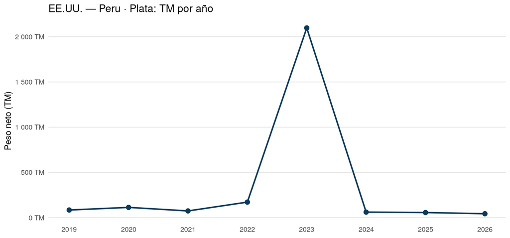

**FOB (USD)**

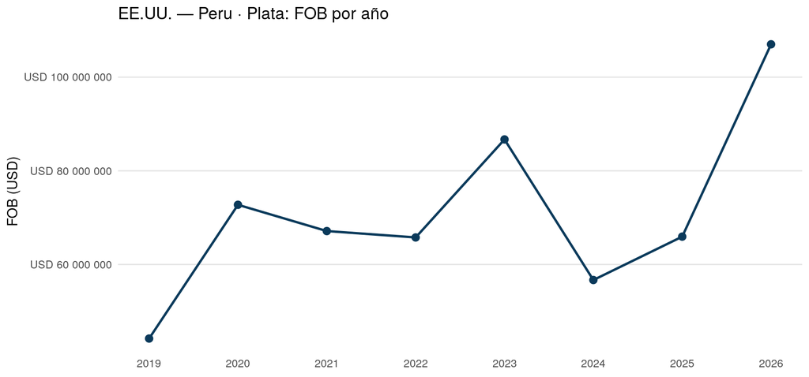

**Principales empresas exportadoras (destino EE.UU.)**

**Todo el periodo**

| Exportador | Peso neto | Porcentaje peso neto | FOB (USD) | Registros |
| --- | --- | --- | --- | --- |
| BLUEQUEST PERU SOCIEDAD ANONIMA CERRADA - BLUEQUEST PERU S.A.C. | 1 990,19 TM | 73,6% | USD 1,4 millones | 1 |
| SOUTHERN PERU COPPER CORPORATION, SUCURSAL DEL PERÚ | 473,21 TM | 17,5% | USD 422,4 millones | 160 |
| OXIDOS DE PASCO S.A.C. | 125,49 TM | 4,6% | USD 103,8 millones | 34 |
| APUMAYO S.A.C. | 6,25 TM | 0,2% | USD 4,5 millones | 12 |
| ECORE TRADING S.A.C. | 6,17 TM | 0,2% | USD 7,1 millones | 20 |
| EMPRESA ADMINISTRADORA CERRO S.A.C. | 5,89 TM | 0,2% | USD 7,3 millones | 1 |
| LA JOYA MINING SOCIEDAD ANONIMA CERRADA | 3,77 TM | 0,1% | USD 4,7 millones | 339 |
| SOLANDRA S.A.C. | 2,70 TM | 0,1% | USD 4,6 millones | 5 |
| COMPANIA MINERA ARES S.A.C. | 2,29 TM | 0,1% | USD 4,7 millones | 1 |
| ECOSERVICIOS E INGENIERIA LIMPIA SOCIEDAD ANONIMA CERRADA - EIL S.A.C. | 0,66 TM | 0,0% | USD 1,4 millones | 1 |

**2025**

| Exportador | Peso neto | Porcentaje peso neto | FOB (USD) | Registros |
| --- | --- | --- | --- | --- |
| SOUTHERN PERU COPPER CORPORATION, SUCURSAL DEL PERÚ | 54,90 TM | 96,6% | USD 63,8 millones | 28 |
| SOLANDRA S.A.C. | 1,05 TM | 1,8% | USD 1,1 millones | 2 |
| ECORE TRADING S.A.C. | 0,68 TM | 1,2% | USD 853 654 | 1 |
| RAMCOPERU E.I.R.L. | 0,14 TM | 0,3% | USD 160 039 | 15 |
| AGP PERU S.A.C EN LIQUIDACIÓN | 0,06 TM | 0,1% | USD 26 450 | 1 |
| TERA TRADE S.A.C. | 0,01 TM | 0,0% | USD 9 744 | 2 |

### Arsénico (a EE.UU.)

Hacia Estados Unidos, **Arsénico** desde **Peru** suma 40,00 TM netas y USD 82 480 FOB (1 registros); eso es el **100,0%** del tonelaje de Arsénico exportado a todos los destinos.

**Evolución anual hacia EE.UU.**

**Peso neto (TM)**

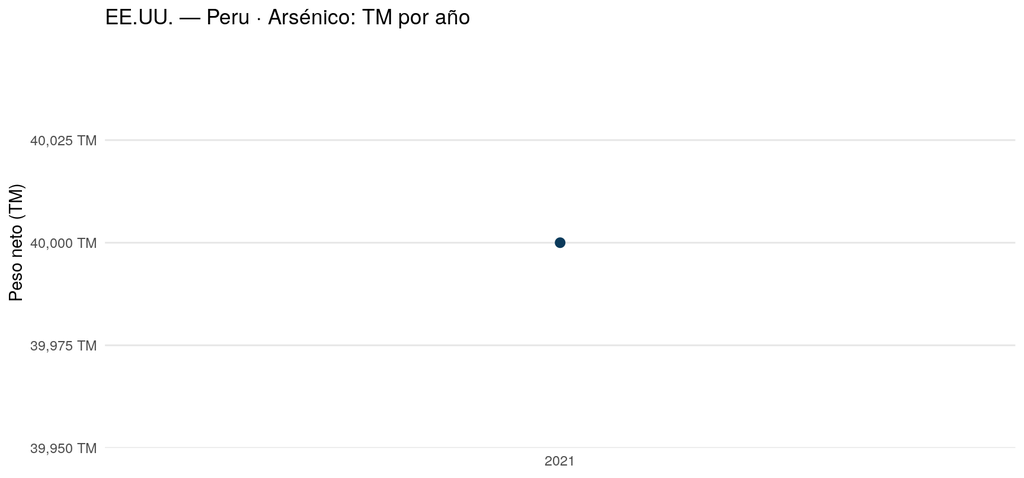

**FOB (USD)**

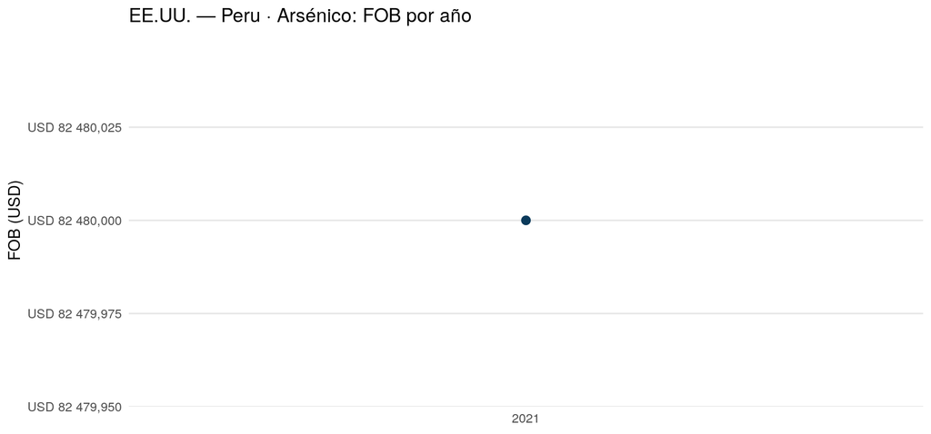

**Principales empresas exportadoras (destino EE.UU.)**

**Todo el periodo**

| Exportador | Peso neto | Porcentaje peso neto | FOB (USD) | Registros |
| --- | --- | --- | --- | --- |
| ZINC INDUSTRIAS NACIONALES S A | 40,00 TM | 100,0% | USD 82 480 | 1 |

**2025**

| Exportador | Peso neto |
| --- | --- |
| — | — |

### Baritina (a EE.UU.)

Hacia Estados Unidos, **Baritina** desde **Peru** suma 0,03 TM netas y USD 105 FOB (1 registros); eso es el **0,0%** del tonelaje de Baritina exportado a todos los destinos; en **2025**: 0,03 TM y USD 105 (1 registros).

**Evolución anual hacia EE.UU.**

**Peso neto (TM)**

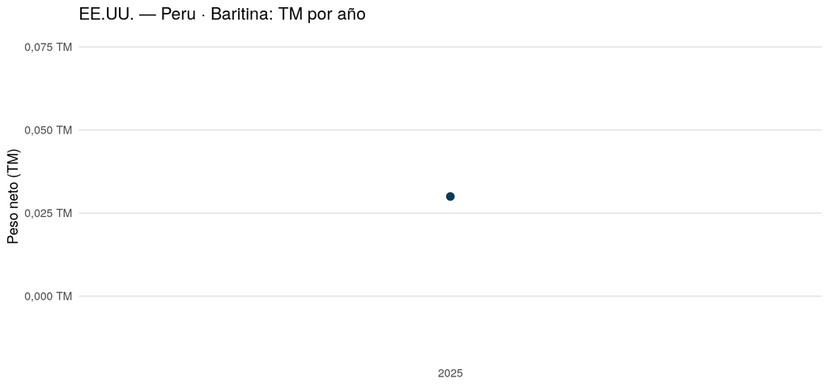

**FOB (USD)**

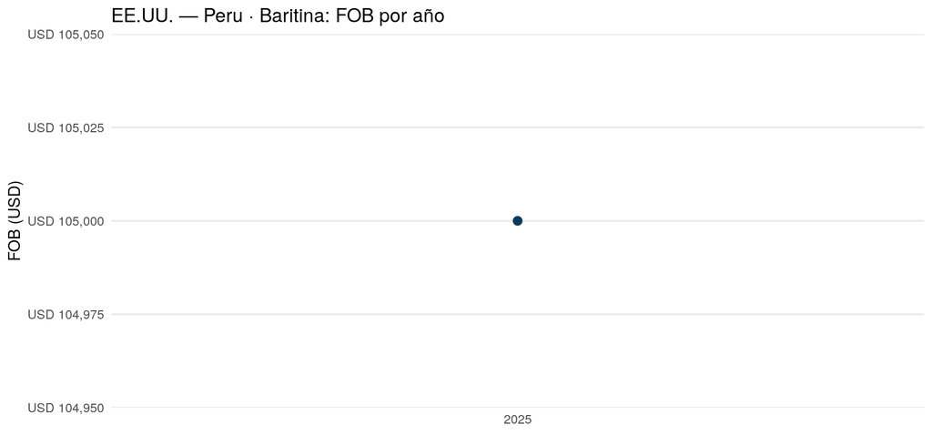

**Principales empresas exportadoras (destino EE.UU.)**

**Todo el periodo**

| Exportador | Peso neto | Porcentaje peso neto | FOB (USD) | Registros |
| --- | --- | --- | --- | --- |
| DIEGO MINERAL’S S.R.L. | 0,03 TM | 100,0% | USD 105 | 1 |

**2025**

| Exportador | Peso neto | Porcentaje peso neto | FOB (USD) | Registros |
| --- | --- | --- | --- | --- |
| DIEGO MINERAL’S S.R.L. | 0,03 TM | 100,0% | USD 105 | 1 |

## A EE.UU. · Chile

En la tabla, **Porcentaje peso neto** es la participación de cada mineral en el tonelaje de este país hacia EE.UU. **Porcentaje de todo exportado** (columna sombreada) es el peso neto (TM) enviado a EE.UU. de ese mineral dividido entre el peso neto del mismo mineral exportado a **todos** los destinos en el scrape. Ejemplo: si Perú exporta 412 396 TM de cobre a EE.UU., la columna sombreada dice qué fracción son de todo el cobre peruano exportado (todos los países).

| Mineral | Peso neto | Porcentaje peso neto | FOB (USD) | Porcentaje de todo exportado | Registros |
| --- | --- | --- | --- | --- | --- |
| Cobre | 4 493 643,33 TM | 98,3% | USD 41 225,6 millones | 3,8% | 7 851 |
| Litio | 54 799,37 TM | 1,2% | USD 756,4 millones | 3,8% | 3 980 |
| Boro | 19 930,86 TM | 0,4% | USD 14,4 millones | 2,8% | 298 |
| Plomo | 1 276,75 TM | 0,0% | USD 2,4 millones | 1,4% | 7 |
| Plata | 1 197,61 TM | 0,0% | USD 1 133,2 millones | 75,1% | 878 |
| Renio | 82,00 TM | 0,0% | USD 159,3 millones | 94,9% | 140 |

### Cobre (a EE.UU.)

Hacia Estados Unidos, **Cobre** desde **Chile** suma 4 493 643,33 TM netas y USD 41 225,6 millones FOB (7 851 registros); eso es el **3,8%** del tonelaje de Cobre exportado a todos los destinos; en **2025**: 787 443,46 TM y USD 7 922,3 millones (1 260 registros).

**Evolución anual hacia EE.UU.**

**Peso neto (TM)**

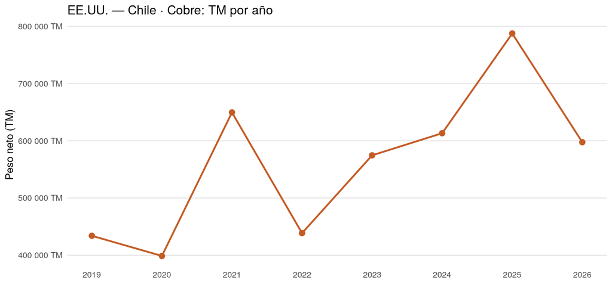

**FOB (USD)**

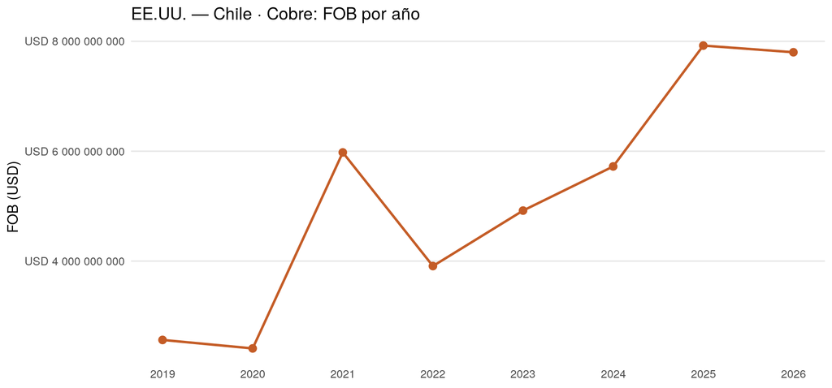

**Principales empresas exportadoras (destino EE.UU.)**

**Todo el periodo**

| Exportador | Peso neto | Porcentaje peso neto | FOB (USD) | Registros |
| --- | --- | --- | --- | --- |
| CORP NACIONAL DEL COBRE DE CHILE | 1 972 047,40 TM | 43,9% | USD 17 853,3 millones | 3 665 |
| MINERA ESCONDIDA LIMITADA | 576 152,74 TM | 12,8% | USD 5 068,0 millones | 629 |
| SOC CONTRACTUAL MINERA EL ABRA | 430 877,18 TM | 9,6% | USD 3 913,2 millones | 641 |
| Sin dato | 404 448,57 TM | 9,0% | USD 3 511,5 millones | 821 |
| MINERA SPENCE S A | 305 936,72 TM | 6,8% | USD 2 997,0 millones | 333 |
| MINERA ANTUCOYA | 157 332,32 TM | 3,5% | USD 1 637,1 millones | 282 |
| MINERA LAS CENIZAS S A | 144 256,31 TM | 3,2% | USD 1 363,3 millones | 277 |
| ANGLO AMERICAN NORTE S.A. | 90 241,31 TM | 2,0% | USD 859,8 millones | 190 |
| COMPANIA MINERA ZALDIVAR SPA | 81 333,47 TM | 1,8% | USD 846,4 millones | 95 |
| MINERA ESPERANZA | 78 765,68 TM | 1,8% | USD 778,7 millones | 127 |

**2025**

| Exportador | Peso neto | Porcentaje peso neto | FOB (USD) | Registros |
| --- | --- | --- | --- | --- |
| CORP NACIONAL DEL COBRE DE CHILE | 282 823,97 TM | 35,9% | USD 2 931,8 millones | 468 |
| MINERA ESCONDIDA LIMITADA | 98 235,26 TM | 12,5% | USD 980,6 millones | 86 |
| SOC CONTRACTUAL MINERA EL ABRA | 87 256,72 TM | 11,1% | USD 845,4 millones | 109 |
| MINERA SPENCE S A | 78 204,92 TM | 9,9% | USD 787,6 millones | 79 |
| MINERA ANTUCOYA | 49 405,83 TM | 6,3% | USD 486,7 millones | 76 |
| COMPANIA MINERA ZALDIVAR SPA | 32 964,98 TM | 4,2% | USD 332,3 millones | 32 |
| MINERA LAS CENIZAS S A | 30 649,22 TM | 3,9% | USD 297,7 millones | 56 |
| ANGLO AMERICAN NORTE S.A. | 23 981,81 TM | 3,0% | USD 234,7 millones | 47 |
| SCM MINERA LUMINA COPPER CHILE | 23 789,63 TM | 3,0% | USD 235,5 millones | 43 |
| MINERA ESPERANZA | 22 584,97 TM | 2,9% | USD 219,4 millones | 32 |

### Litio (a EE.UU.)

Hacia Estados Unidos, **Litio** desde **Chile** suma 54 799,37 TM netas y USD 756,4 millones FOB (3 980 registros); eso es el **3,8%** del tonelaje de Litio exportado a todos los destinos; en **2025**: 6 687,93 TM y USD 63,7 millones (552 registros).

**Evolución anual hacia EE.UU.**

**Peso neto (TM)**

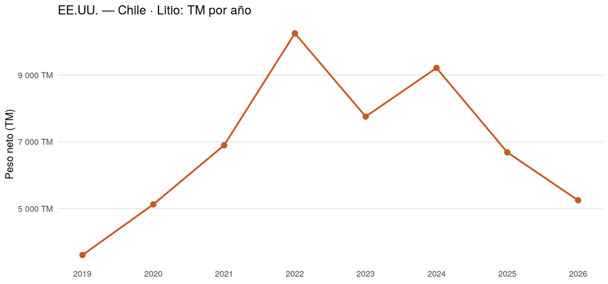

**FOB (USD)**

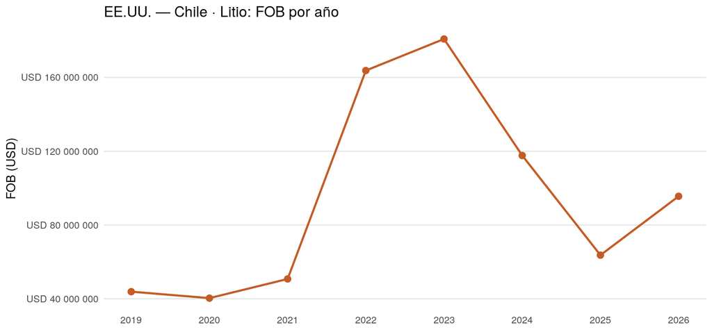

**Principales empresas exportadoras (destino EE.UU.)**

**Todo el periodo**

| Exportador | Peso neto | Porcentaje peso neto | FOB (USD) | Registros |
| --- | --- | --- | --- | --- |
| S Q M SALAR S A | 29 946,71 TM | 54,6% | USD 440,3 millones | 2 297 |
| SOC CHILENA DE LITIO LTDA | 20 407,98 TM | 37,2% | USD 280,9 millones | 1 430 |
| Sin dato | 4 046,56 TM | 7,4% | USD 29,7 millones | 234 |
| YUMBES S C M | 303,14 TM | 0,6% | USD 4,7 millones | 15 |
| OUTOTEC (CHILE) S A | 94,98 TM | 0,2% | USD 761 139 | 4 |

**2025**

| Exportador | Peso neto | Porcentaje peso neto | FOB (USD) | Registros |
| --- | --- | --- | --- | --- |
| S Q M SALAR S A | 4 732,64 TM | 70,8% | USD 50,3 millones | 358 |
| SOC CHILENA DE LITIO LTDA | 1 955,29 TM | 29,2% | USD 13,4 millones | 194 |